# Homework 3&4

Ibrahim Aykut

19 06 2021

```r
library("dplyr")
library("lubridate")
library("glmnet")
```

I read file and manipulated the data.

```r
aaa=read.csv2("GercekZamanliTuketim-01012016-31052021newnew.csv")
aaa$Tüketim.Miktarı..MWh.=as.numeric(aaa$Tüketim.Miktarı..MWh.)
y1=mutate(aaa,tarih=dmy(Tarih))
```

## Question A

I added lag48 and lag168 values to the data frame and calculated the error.

```r
lag48=lag(y1,48)
lag168=lag(y1,168)
new=mutate(y1,lag48tüketim=lag48$Tüketim.Miktarı..MWh.,lag168tüketim=lag168$Tüketim.Miktarı..MWh.,lag48error=(abs((lag48$Tüketim.Miktarı..MWh.-y1$Tüketim.Miktarı..MWh.)/y1$Tüketim.Miktarı..MWh.))*100,lag168error=(abs((lag168$Tüketim.Miktarı..MWh.-y1$Tüketim.Miktarı..MWh.)/y1$Tüketim.Miktarı..MWh.))*100)
```

```r
filtre<-filter(new,tarih>=as_date('2021-05-01'))
```

```r
summary(filtre$lag48error)
```

```
##     Min.  1st Qu.   Median     Mean  3rd Qu.     Max.
##  0.00384  2.09289  7.30250  9.26289 13.20968 46.71555
```

```r
summary(filtre$lag168error)
```

```
##     Min.  1st Qu.   Median     Mean  3rd Qu.     Max.
##  0.01239  1.35130  4.11998  9.82937 13.74725 60.43751
```

```r
quantile(filtre$lag48error,probs = c(0,0.1,0.25,0.5,0.75,0.9))
```

```
##           0%          10%          25%          50%          75%          90%
##  0.003841994  0.731086953  2.092888146  7.302496843 13.209679560 22.641938385
```

```r
quantile(filtre$lag168error,probs = c(0,0.1,0.25,0.5,0.75,0.9))
```

```
##          0%         10%         25%         50%         75%         90%
##  0.01238552  0.44992574  1.35130473  4.11998310 13.74725400 29.72958914
```

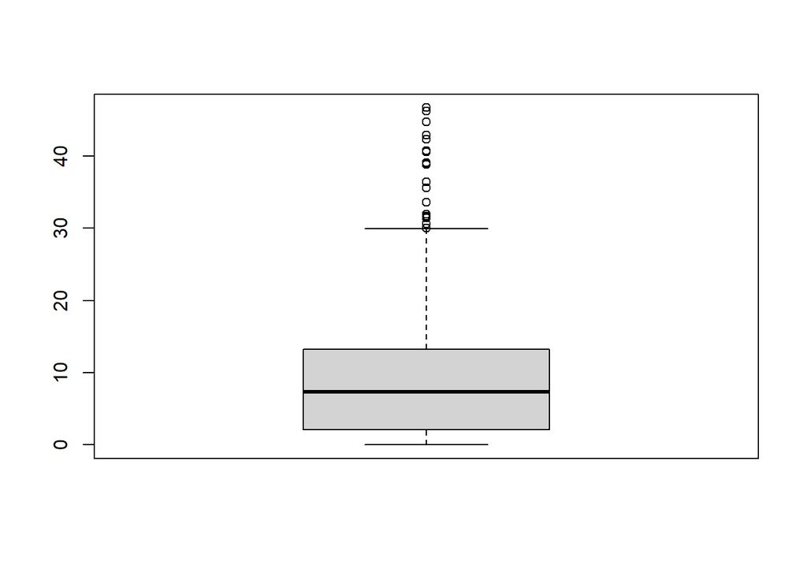

```r
boxplot(filtre$lag48error)
```

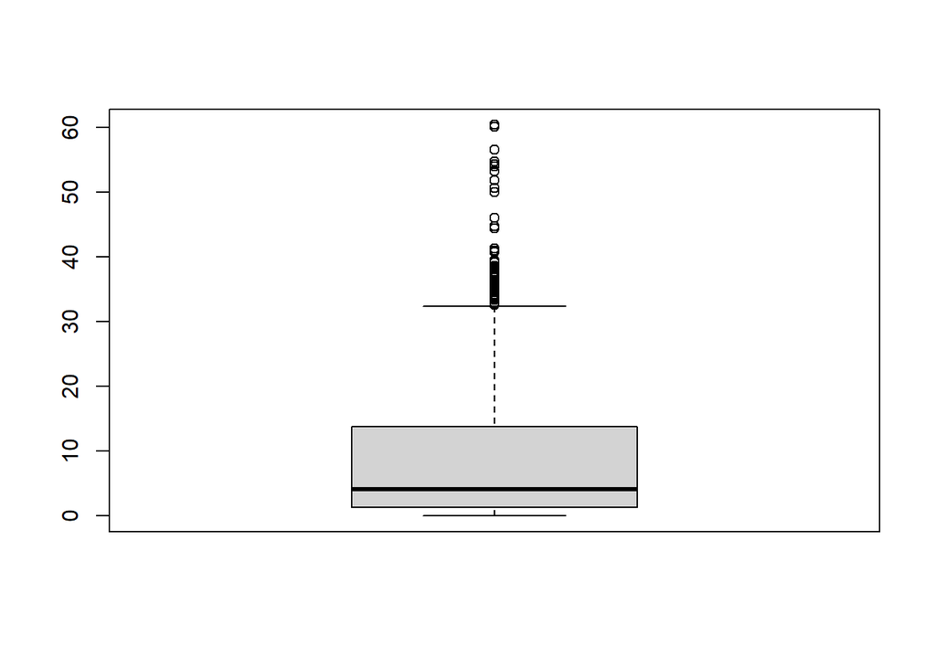

```r
boxplot(filtre$lag168error)
```

## Question B

I added lag48 and lag168 values to the data frame and gave a row number to each row in order to filter the data.

```r
new=mutate(y1,lag48tüketim=lag48$Tüketim.Miktarı..MWh.,lag168tüketim=lag168$Tüketim.Miktarı..MWh.)
new$rownumber=1:nrow(new)
new=filter(new,rownumber>168)
```

I filtered the training and test datasets.

```r
trainingdata=filter(new,tarih>=as_date('2016-01-08'),tarih<as_date('2020-03-01'))
testdata=filter(new,tarih>=as_date('2020-03-01'))
```

I run linear regression for training data.

```r
linear_model=lm(Tüketim.Miktarı..MWh.~lag48tüketim+lag168tüketim,data=trainingdata)
summary(linear_model)
```

```
##
## Call:
## lm(formula = Tüketim.Miktarı..MWh. ~ lag48tüketim + lag168tüketim,
##     data = trainingdata)
##
## Residuals:
##      Min       1Q   Median       3Q      Max
## -25267.5   -977.0     -7.9    995.1  16067.2
##
## Coefficients:
##                Estimate Std. Error t value Pr(>|t|)
## (Intercept)   1.632e+03  9.200e+01   17.74   <2e-16 ***
## lag48tüketim  3.097e-01  3.342e-03   92.67   <2e-16 ***
## lag168tüketim 6.409e-01  3.337e-03  192.03   <2e-16 ***
## ---
## Signif. codes:  0 '***' 0.001 '**' 0.01 '*' 0.05 '.' 0.1 ' ' 1
##
## Residual standard error: 2372 on 36333 degrees of freedom
## Multiple R-squared:  0.7678, Adjusted R-squared:  0.7678
## F-statistic: 6.006e+04 on 2 and 36333 DF,  p-value: < 2.2e-16
```

I made a prediction for testdata.

```r
predicted_model=predict(linear_model,testdata)
```

I calculated MAPE and added them to the dataframe.

```r
testdata<-mutate(testdata,MAPE=(abs((testdata$Tüketim.Miktarı..MWh.-predicted_model)/testdata$Tüketim.Miktarı..MWh.)*100))
```

```r
summary(testdata$MAPE)
```

```
##     Min.  1st Qu.   Median     Mean  3rd Qu.     Max.
##  0.00011  1.43288  3.26338  5.16363  6.47425 70.63150
```

## Question C

I manipulated hour values to be able to filter them.

```r
y11=y1 %>% mutate(saat=hm(Saat)) %>% mutate(saat=hour(saat))
```

I added lag48 and lag168 values to the data frame.

```r
lag48=lag(y11,48)
lag168=lag(y11,168)
new=mutate(y11,lag48tüketim=lag48$Tüketim.Miktarı..MWh.,lag168tüketim=lag168$Tüketim.Miktarı..MWh.)
new$rownumber=1:nrow(new)
new=filter(new,rownumber>168)
```

Training data for each hour.

```r
trainingdata0=filter(new,tarih>=as_date('2016-01-08'),tarih<as_date('2020-03-01'),saat==0)
trainingdata1=filter(new,tarih>=as_date('2016-01-08'),tarih<as_date('2020-03-01'),saat==1)
trainingdata2=filter(new,tarih>=as_date('2016-01-08'),tarih<as_date('2020-03-01'),saat==2)
trainingdata3=filter(new,tarih>=as_date('2016-01-08'),tarih<as_date('2020-03-01'),saat==3)
trainingdata4=filter(new,tarih>=as_date('2016-01-08'),tarih<as_date('2020-03-01'),saat==4)
trainingdata5=filter(new,tarih>=as_date('2016-01-08'),tarih<as_date('2020-03-01'),saat==5)
trainingdata6=filter(new,tarih>=as_date('2016-01-08'),tarih<as_date('2020-03-01'),saat==6)
trainingdata7=filter(new,tarih>=as_date('2016-01-08'),tarih<as_date('2020-03-01'),saat==7)
trainingdata8=filter(new,tarih>=as_date('2016-01-08'),tarih<as_date('2020-03-01'),saat==8)
trainingdata9=filter(new,tarih>=as_date('2016-01-08'),tarih<as_date('2020-03-01'),saat==9)
trainingdata10=filter(new,tarih>=as_date('2016-01-08'),tarih<as_date('2020-03-01'),saat==10)
trainingdata11=filter(new,tarih>=as_date('2016-01-08'),tarih<as_date('2020-03-01'),saat==11)
trainingdata12=filter(new,tarih>=as_date('2016-01-08'),tarih<as_date('2020-03-01'),saat==12)
trainingdata13=filter(new,tarih>=as_date('2016-01-08'),tarih<as_date('2020-03-01'),saat==13)
trainingdata14=filter(new,tarih>=as_date('2016-01-08'),tarih<as_date('2020-03-01'),saat==14)
trainingdata15=filter(new,tarih>=as_date('2016-01-08'),tarih<as_date('2020-03-01'),saat==15)
trainingdata16=filter(new,tarih>=as_date('2016-01-08'),tarih<as_date('2020-03-01'),saat==16)
trainingdata17=filter(new,tarih>=as_date('2016-01-08'),tarih<as_date('2020-03-01'),saat==17)
trainingdata18=filter(new,tarih>=as_date('2016-01-08'),tarih<as_date('2020-03-01'),saat==18)
trainingdata19=filter(new,tarih>=as_date('2016-01-08'),tarih<as_date('2020-03-01'),saat==19)
trainingdata20=filter(new,tarih>=as_date('2016-01-08'),tarih<as_date('2020-03-01'),saat==20)
trainingdata21=filter(new,tarih>=as_date('2016-01-08'),tarih<as_date('2020-03-01'),saat==21)
trainingdata22=filter(new,tarih>=as_date('2016-01-08'),tarih<as_date('2020-03-01'),saat==22)
trainingdata23=filter(new,tarih>=as_date('2016-01-08'),tarih<as_date('2020-03-01'),saat==23)
```

Test data for each hour.

```r
testdata0=filter(new,tarih>=as_date('2020-03-01'),saat==0)
testdata1=filter(new,tarih>=as_date('2020-03-01'),saat==1)
testdata2=filter(new,tarih>=as_date('2020-03-01'),saat==2)
testdata3=filter(new,tarih>=as_date('2020-03-01'),saat==3)
testdata4=filter(new,tarih>=as_date('2020-03-01'),saat==4)
testdata5=filter(new,tarih>=as_date('2020-03-01'),saat==5)
testdata6=filter(new,tarih>=as_date('2020-03-01'),saat==6)
testdata7=filter(new,tarih>=as_date('2020-03-01'),saat==7)
testdata8=filter(new,tarih>=as_date('2020-03-01'),saat==8)
testdata9=filter(new,tarih>=as_date('2020-03-01'),saat==9)
testdata10=filter(new,tarih>=as_date('2020-03-01'),saat==10)
testdata11=filter(new,tarih>=as_date('2020-03-01'),saat==11)
testdata12=filter(new,tarih>=as_date('2020-03-01'),saat==12)
testdata13=filter(new,tarih>=as_date('2020-03-01'),saat==13)
testdata14=filter(new,tarih>=as_date('2020-03-01'),saat==14)
testdata15=filter(new,tarih>=as_date('2020-03-01'),saat==15)
testdata16=filter(new,tarih>=as_date('2020-03-01'),saat==16)
testdata17=filter(new,tarih>=as_date('2020-03-01'),saat==17)
testdata18=filter(new,tarih>=as_date('2020-03-01'),saat==18)
testdata19=filter(new,tarih>=as_date('2020-03-01'),saat==19)
testdata20=filter(new,tarih>=as_date('2020-03-01'),saat==20)
testdata21=filter(new,tarih>=as_date('2020-03-01'),saat==21)
testdata22=filter(new,tarih>=as_date('2020-03-01'),saat==22)
testdata23=filter(new,tarih>=as_date('2020-03-01'),saat==23)
```

Linear regression for each hour.

```r
linear_model0=lm(Tüketim.Miktarı..MWh.~lag48tüketim+lag168tüketim,data=trainingdata0)
linear_model1=lm(Tüketim.Miktarı..MWh.~lag48tüketim+lag168tüketim,data=trainingdata1)
linear_model2=lm(Tüketim.Miktarı..MWh.~lag48tüketim+lag168tüketim,data=trainingdata2)
linear_model3=lm(Tüketim.Miktarı..MWh.~lag48tüketim+lag168tüketim,data=trainingdata3)
linear_model4=lm(Tüketim.Miktarı..MWh.~lag48tüketim+lag168tüketim,data=trainingdata4)
linear_model5=lm(Tüketim.Miktarı..MWh.~lag48tüketim+lag168tüketim,data=trainingdata5)
linear_model6=lm(Tüketim.Miktarı..MWh.~lag48tüketim+lag168tüketim,data=trainingdata6)
linear_model7=lm(Tüketim.Miktarı..MWh.~lag48tüketim+lag168tüketim,data=trainingdata7)
linear_model8=lm(Tüketim.Miktarı..MWh.~lag48tüketim+lag168tüketim,data=trainingdata8)
linear_model9=lm(Tüketim.Miktarı..MWh.~lag48tüketim+lag168tüketim,data=trainingdata9)
linear_model10=lm(Tüketim.Miktarı..MWh.~lag48tüketim+lag168tüketim,data=trainingdata10)
linear_model11=lm(Tüketim.Miktarı..MWh.~lag48tüketim+lag168tüketim,data=trainingdata11)
linear_model12=lm(Tüketim.Miktarı..MWh.~lag48tüketim+lag168tüketim,data=trainingdata12)
linear_model13=lm(Tüketim.Miktarı..MWh.~lag48tüketim+lag168tüketim,data=trainingdata13)
linear_model14=lm(Tüketim.Miktarı..MWh.~lag48tüketim+lag168tüketim,data=trainingdata14)
linear_model15=lm(Tüketim.Miktarı..MWh.~lag48tüketim+lag168tüketim,data=trainingdata15)
linear_model16=lm(Tüketim.Miktarı..MWh.~lag48tüketim+lag168tüketim,data=trainingdata16)
linear_model17=lm(Tüketim.Miktarı..MWh.~lag48tüketim+lag168tüketim,data=trainingdata17)
linear_model18=lm(Tüketim.Miktarı..MWh.~lag48tüketim+lag168tüketim,data=trainingdata18)
linear_model19=lm(Tüketim.Miktarı..MWh.~lag48tüketim+lag168tüketim,data=trainingdata19)
linear_model20=lm(Tüketim.Miktarı..MWh.~lag48tüketim+lag168tüketim,data=trainingdata20)
linear_model21=lm(Tüketim.Miktarı..MWh.~lag48tüketim+lag168tüketim,data=trainingdata21)
linear_model22=lm(Tüketim.Miktarı..MWh.~lag48tüketim+lag168tüketim,data=trainingdata22)
linear_model23=lm(Tüketim.Miktarı..MWh.~lag48tüketim+lag168tüketim,data=trainingdata23)
```

```r
predicted_model0=predict(linear_model0,testdata0)
predicted_model1=predict(linear_model1,testdata1)
predicted_model2=predict(linear_model2,testdata2)
predicted_model3=predict(linear_model3,testdata3)
predicted_model4=predict(linear_model4,testdata4)
predicted_model5=predict(linear_model5,testdata5)
predicted_model6=predict(linear_model6,testdata6)
predicted_model7=predict(linear_model7,testdata7)
predicted_model8=predict(linear_model8,testdata8)
predicted_model9=predict(linear_model9,testdata9)
predicted_model10=predict(linear_model10,testdata10)
predicted_model11=predict(linear_model11,testdata11)
predicted_model12=predict(linear_model12,testdata12)
predicted_model13=predict(linear_model13,testdata13)
predicted_model14=predict(linear_model14,testdata14)
predicted_model15=predict(linear_model15,testdata15)
predicted_model16=predict(linear_model16,testdata16)
predicted_model17=predict(linear_model17,testdata17)
predicted_model18=predict(linear_model18,testdata18)
predicted_model19=predict(linear_model19,testdata19)
predicted_model20=predict(linear_model20,testdata20)
predicted_model21=predict(linear_model20,testdata21)
predicted_model22=predict(linear_model20,testdata22)
predicted_model23=predict(linear_model20,testdata23)
```

I calculated MAPE and added them to the dataframe.

```r
testdata0<-mutate(testdata0,MAPE=(abs((testdata0$Tüketim.Miktarı..MWh.-predicted_model0)/testdata0$Tüketim.Miktarı..MWh.)*100))
testdata1<-mutate(testdata1,MAPE=(abs((testdata1$Tüketim.Miktarı..MWh.-predicted_model1)/testdata1$Tüketim.Miktarı..MWh.)*100))
testdata2<-mutate(testdata2,MAPE=(abs((testdata2$Tüketim.Miktarı..MWh.-predicted_model2)/testdata2$Tüketim.Miktarı..MWh.)*100))
testdata3<-mutate(testdata3,MAPE=(abs((testdata3$Tüketim.Miktarı..MWh.-predicted_model3)/testdata3$Tüketim.Miktarı..MWh.)*100))
testdata4<-mutate(testdata4,MAPE=(abs((testdata4$Tüketim.Miktarı..MWh.-predicted_model4)/testdata4$Tüketim.Miktarı..MWh.)*100))
testdata5<-mutate(testdata5,MAPE=(abs((testdata5$Tüketim.Miktarı..MWh.-predicted_model5)/testdata5$Tüketim.Miktarı..MWh.)*100))
testdata6<-mutate(testdata6,MAPE=(abs((testdata6$Tüketim.Miktarı..MWh.-predicted_model6)/testdata6$Tüketim.Miktarı..MWh.)*100))
testdata7<-mutate(testdata7,MAPE=(abs((testdata7$Tüketim.Miktarı..MWh.-predicted_model7)/testdata7$Tüketim.Miktarı..MWh.)*100))
testdata8<-mutate(testdata8,MAPE=(abs((testdata8$Tüketim.Miktarı..MWh.-predicted_model8)/testdata8$Tüketim.Miktarı..MWh.)*100))
testdata9<-mutate(testdata9,MAPE=(abs((testdata9$Tüketim.Miktarı..MWh.-predicted_model9)/testdata9$Tüketim.Miktarı..MWh.)*100))
testdata10<-mutate(testdata10,MAPE=(abs((testdata10$Tüketim.Miktarı..MWh.-predicted_model10)/testdata10$Tüketim.Miktarı..MWh.)*100))
testdata11<-mutate(testdata11,MAPE=(abs((testdata11$Tüketim.Miktarı..MWh.-predicted_model11)/testdata11$Tüketim.Miktarı..MWh.)*100))
testdata12<-mutate(testdata12,MAPE=(abs((testdata12$Tüketim.Miktarı..MWh.-predicted_model12)/testdata12$Tüketim.Miktarı..MWh.)*100))
testdata13<-mutate(testdata13,MAPE=(abs((testdata13$Tüketim.Miktarı..MWh.-predicted_model13)/testdata13$Tüketim.Miktarı..MWh.)*100))
testdata14<-mutate(testdata14,MAPE=(abs((testdata14$Tüketim.Miktarı..MWh.-predicted_model14)/testdata14$Tüketim.Miktarı..MWh.)*100))
testdata15<-mutate(testdata15,MAPE=(abs((testdata15$Tüketim.Miktarı..MWh.-predicted_model15)/testdata15$Tüketim.Miktarı..MWh.)*100))
testdata16<-mutate(testdata16,MAPE=(abs((testdata16$Tüketim.Miktarı..MWh.-predicted_model16)/testdata16$Tüketim.Miktarı..MWh.)*100))
testdata17<-mutate(testdata17,MAPE=(abs((testdata17$Tüketim.Miktarı..MWh.-predicted_model17)/testdata17$Tüketim.Miktarı..MWh.)*100))
testdata18<-mutate(testdata18,MAPE=(abs((testdata18$Tüketim.Miktarı..MWh.-predicted_model18)/testdata18$Tüketim.Miktarı..MWh.)*100))
testdata19<-mutate(testdata19,MAPE=(abs((testdata19$Tüketim.Miktarı..MWh.-predicted_model19)/testdata19$Tüketim.Miktarı..MWh.)*100))
testdata20<-mutate(testdata20,MAPE=(abs((testdata20$Tüketim.Miktarı..MWh.-predicted_model20)/testdata20$Tüketim.Miktarı..MWh.)*100))
testdata21<-mutate(testdata21,MAPE=(abs((testdata21$Tüketim.Miktarı..MWh.-predicted_model21)/testdata21$Tüketim.Miktarı..MWh.)*100))
testdata22<-mutate(testdata22,MAPE=(abs((testdata22$Tüketim.Miktarı..MWh.-predicted_model22)/testdata22$Tüketim.Miktarı..MWh.)*100))
testdata23<-mutate(testdata23,MAPE=(abs((testdata23$Tüketim.Miktarı..MWh.-predicted_model23)/testdata23$Tüketim.Miktarı..MWh.)*100))
```

Summary of MAPE values.

```r
summary(testdata0$MAPE)
```

```
##     Min.  1st Qu.   Median     Mean  3rd Qu.     Max.
##  0.01593  1.28406  2.87981  3.78658  5.04444 34.37125
```

```r
summary(testdata1$MAPE)
```

```
##     Min.  1st Qu.   Median     Mean  3rd Qu.     Max.
##  0.00013  1.39850  3.04308  3.85883  5.04794 37.39438
```

```r
summary(testdata2$MAPE)
```

```
##     Min.  1st Qu.   Median     Mean  3rd Qu.     Max.
##  0.01103  1.42873  3.17847  4.02642  5.03749 42.63754
```

```r
summary(testdata3$MAPE)
```

```
##     Min.  1st Qu.   Median     Mean  3rd Qu.     Max.
##  0.00975  1.41372  3.19717  4.00702  5.04187 42.29618
```

```r
summary(testdata4$MAPE)
```

```
##     Min.  1st Qu.   Median     Mean  3rd Qu.     Max.
##  0.00092  1.36727  3.16781  4.02078  5.21395 39.63887
```

```r
summary(testdata5$MAPE)
```

```
##     Min.  1st Qu.   Median     Mean  3rd Qu.     Max.
##  0.01425  1.36166  3.07787  4.06610  5.14284 37.81037
```

```r
summary(testdata6$MAPE)
```

```
##     Min.  1st Qu.   Median     Mean  3rd Qu.     Max.
##  0.02556  1.17852  2.93142  4.21977  5.32303 36.95801
```

```r
summary(testdata7$MAPE)
```

```
##     Min.  1st Qu.   Median     Mean  3rd Qu.     Max.
##  0.01688  1.14351  3.27358  4.80102  5.92354 42.11643
```

```r
summary(testdata8$MAPE)
```

```
##     Min.  1st Qu.   Median     Mean  3rd Qu.     Max.
##  0.02045  1.60245  4.02018  6.31676  7.80223 55.87622
```

```r
summary(testdata9$MAPE)
```

```
##     Min.  1st Qu.   Median     Mean  3rd Qu.     Max.
##  0.02288  1.73808  4.80242  7.04288  8.73996 64.92012
```

```r
summary(testdata10$MAPE)
```

```
##     Min.  1st Qu.   Median     Mean  3rd Qu.     Max.
##  0.02527  1.99417  5.05555  7.16089  9.21311 68.93167
```

```r
summary(testdata11$MAPE)
```

```
##     Min.  1st Qu.   Median     Mean  3rd Qu.     Max.
##  0.03407  2.06986  4.97892  7.17153  9.27173 69.36252
```

```r
summary(testdata12$MAPE)
```

```
##     Min.  1st Qu.   Median     Mean  3rd Qu.     Max.
##  0.00683  2.22736  4.68112  6.91624  8.91640 61.98122
```

```r
summary(testdata13$MAPE)
```

```
##    Min. 1st Qu.  Median    Mean 3rd Qu.    Max.
##  0.0021  2.2233  4.8946  6.9025  8.9137 59.9993
```

```r
summary(testdata14$MAPE)
```

```
##     Min.  1st Qu.   Median     Mean  3rd Qu.     Max.
##  0.01262  2.44287  4.91718  7.04970  8.81801 65.88618
```

```r
summary(testdata15$MAPE)
```

```
##     Min.  1st Qu.   Median     Mean  3rd Qu.     Max.
##  0.01245  2.21056  5.01954  6.85168  8.63032 70.97205
```

```r
summary(testdata16$MAPE)
```

```
##     Min.  1st Qu.   Median     Mean  3rd Qu.     Max.
##  0.01299  1.99664  4.64222  6.44090  7.91107 67.05177
```

```r
summary(testdata17$MAPE)
```

```
##     Min.  1st Qu.   Median     Mean  3rd Qu.     Max.
##  0.00024  1.90851  4.16724  5.76815  7.16624 60.32857
```

```r
summary(testdata18$MAPE)
```

```
##     Min.  1st Qu.   Median     Mean  3rd Qu.     Max.
##  0.00083  1.62040  3.42900  4.80428  6.03650 52.83224
```

```r
summary(testdata19$MAPE)
```

```
##     Min.  1st Qu.   Median     Mean  3rd Qu.     Max.
##  0.03327  1.38389  3.11553  4.24553  5.25850 48.11373
```

```r
summary(testdata20$MAPE)
```

```
##     Min.  1st Qu.   Median     Mean  3rd Qu.     Max.
##  0.00761  1.38559  2.88003  3.86372  4.97286 36.01662
```

```r
summary(testdata21$MAPE)
```

```
##     Min.  1st Qu.   Median     Mean  3rd Qu.     Max.
##  0.03299  1.32280  2.83902  3.82917  4.97200 35.45646
```

```r
summary(testdata22$MAPE)
```

```
##    Min. 1st Qu.  Median    Mean 3rd Qu.    Max.
##   0.037   1.198   2.841   3.817   5.062  36.063
```

```r
summary(testdata23$MAPE)
```

```
##     Min.  1st Qu.   Median     Mean  3rd Qu.     Max.
##  0.00335  1.16717  2.75477  3.80054  5.02811 35.74917
```

## Question D

I got 2 days ago’s electrical consumption for each hour.

```r
lag48_0=lag(y11,48)
lag48_1=lag(y11,47)
lag48_2=lag(y11,46)
lag48_3=lag(y11,45)
lag48_4=lag(y11,44)
lag48_5=lag(y11,43)
lag48_6=lag(y11,42)
lag48_7=lag(y11,41)
lag48_8=lag(y11,40)
lag48_9=lag(y11,39)
lag48_10=lag(y11,38)
lag48_11=lag(y11,37)
lag48_12=lag(y11,36)
lag48_13=lag(y11,35)
lag48_14=lag(y11,34)
lag48_15=lag(y11,33)
lag48_16=lag(y11,32)
lag48_17=lag(y11,31)
lag48_18=lag(y11,30)
lag48_19=lag(y11,29)
lag48_20=lag(y11,28)
lag48_21=lag(y11,27)
lag48_22=lag(y11,26)
lag48_23=lag(y11,25)
```

I got last week’s electrical consumption for each hour.

```r
lag168_0=lag(y11,168)
lag168_1=lag(y11,167)
lag168_2=lag(y11,166)
lag168_3=lag(y11,165)
lag168_4=lag(y11,164)
lag168_5=lag(y11,163)
lag168_6=lag(y11,162)
lag168_7=lag(y11,161)
lag168_8=lag(y11,160)
lag168_9=lag(y11,159)
lag168_10=lag(y11,158)
lag168_11=lag(y11,157)
lag168_12=lag(y11,156)
lag168_13=lag(y11,155)
lag168_14=lag(y11,154)
lag168_15=lag(y11,153)
lag168_16=lag(y11,152)
lag168_17=lag(y11,151)
lag168_18=lag(y11,150)
lag168_19=lag(y11,149)
lag168_20=lag(y11,148)
lag168_21=lag(y11,147)
lag168_22=lag(y11,146)
lag168_23=lag(y11,145)
```

I added them as a feature to the dataframe.

```r
new=mutate(y11,lag48_0tüketim=lag48_0$Tüketim.Miktarı..MWh.,lag48_1tüketim=lag48_1$Tüketim.Miktarı..MWh.,lag48_2tüketim=lag48_2$Tüketim.Miktarı..MWh.,lag48_3tüketim=lag48_3$Tüketim.Miktarı..MWh.,y11,lag48_4tüketim=lag48_4$Tüketim.Miktarı..MWh.,lag48_5tüketim=lag48_5$Tüketim.Miktarı..MWh.,lag48_6tüketim=lag48_6$Tüketim.Miktarı..MWh.,lag48_7tüketim=lag48_7$Tüketim.Miktarı..MWh.,lag48_8tüketim=lag48_8$Tüketim.Miktarı..MWh.,lag48_9tüketim=lag48_9$Tüketim.Miktarı..MWh.,lag48_10tüketim=lag48_10$Tüketim.Miktarı..MWh.,
           lag48_11tüketim=lag48_11$Tüketim.Miktarı..MWh.,lag48_12tüketim=lag48_12$Tüketim.Miktarı..MWh.,lag48_13tüketim=lag48_13$Tüketim.Miktarı..MWh.,lag48_14tüketim=lag48_14$Tüketim.Miktarı..MWh.,lag48_15tüketim=lag48_15$Tüketim.Miktarı..MWh.,lag48_16tüketim=lag48_16$Tüketim.Miktarı..MWh.,lag48_17tüketim=lag48_17$Tüketim.Miktarı..MWh.,lag48_18tüketim=lag48_18$Tüketim.Miktarı..MWh.,lag48_19tüketim=lag48_19$Tüketim.Miktarı..MWh.,lag48_20tüketim=lag48_20$Tüketim.Miktarı..MWh.,
           lag48_21tüketim=lag48_21$Tüketim.Miktarı..MWh.,lag48_22tüketim=lag48_22$Tüketim.Miktarı..MWh.,lag48_23tüketim=lag48_23$Tüketim.Miktarı..MWh.,
           y11,lag168_0tüketim=lag168_0$Tüketim.Miktarı..MWh.,lag168_1tüketim=lag168_1$Tüketim.Miktarı..MWh.,lag168_2tüketim=lag168_2$Tüketim.Miktarı..MWh.,lag168_3tüketim=lag168_3$Tüketim.Miktarı..MWh.,y11,lag168_4tüketim=lag168_4$Tüketim.Miktarı..MWh.,lag168_5tüketim=lag168_5$Tüketim.Miktarı..MWh.,lag168_6tüketim=lag168_6$Tüketim.Miktarı..MWh.,lag168_7tüketim=lag168_7$Tüketim.Miktarı..MWh.,lag168_8tüketim=lag168_8$Tüketim.Miktarı..MWh.,lag168_9tüketim=lag168_9$Tüketim.Miktarı..MWh.,lag168_10tüketim=lag168_10$Tüketim.Miktarı..MWh.,
           lag168_11tüketim=lag168_11$Tüketim.Miktarı..MWh.,lag168_12tüketim=lag168_12$Tüketim.Miktarı..MWh.,lag168_13tüketim=lag168_13$Tüketim.Miktarı..MWh.,lag168_14tüketim=lag168_14$Tüketim.Miktarı..MWh.,lag168_15tüketim=lag168_15$Tüketim.Miktarı..MWh.,lag168_16tüketim=lag168_16$Tüketim.Miktarı..MWh.,lag168_17tüketim=lag168_17$Tüketim.Miktarı..MWh.,lag168_18tüketim=lag168_18$Tüketim.Miktarı..MWh.,lag168_19tüketim=lag168_19$Tüketim.Miktarı..MWh.,lag168_20tüketim=lag168_20$Tüketim.Miktarı..MWh.,
           lag168_21tüketim=lag168_21$Tüketim.Miktarı..MWh.,lag168_22tüketim=lag168_22$Tüketim.Miktarı..MWh.,lag168_23tüketim=lag168_23$Tüketim.Miktarı..MWh.)
```

```r
new$rownumber=1:nrow(new)
new=filter(new,rownumber>168)
```

Training data for each hour.

```r
trainingdata0=filter(new,tarih>=as_date('2016-01-08'),tarih<as_date('2020-03-01'),saat==0)
trainingdata1=filter(new,tarih>=as_date('2016-01-08'),tarih<as_date('2020-03-01'),saat==1)
trainingdata2=filter(new,tarih>=as_date('2016-01-08'),tarih<as_date('2020-03-01'),saat==2)
trainingdata3=filter(new,tarih>=as_date('2016-01-08'),tarih<as_date('2020-03-01'),saat==3)
trainingdata4=filter(new,tarih>=as_date('2016-01-08'),tarih<as_date('2020-03-01'),saat==4)
trainingdata5=filter(new,tarih>=as_date('2016-01-08'),tarih<as_date('2020-03-01'),saat==5)
trainingdata6=filter(new,tarih>=as_date('2016-01-08'),tarih<as_date('2020-03-01'),saat==6)
trainingdata7=filter(new,tarih>=as_date('2016-01-08'),tarih<as_date('2020-03-01'),saat==7)
trainingdata8=filter(new,tarih>=as_date('2016-01-08'),tarih<as_date('2020-03-01'),saat==8)
trainingdata9=filter(new,tarih>=as_date('2016-01-08'),tarih<as_date('2020-03-01'),saat==9)
trainingdata10=filter(new,tarih>=as_date('2016-01-08'),tarih<as_date('2020-03-01'),saat==10)
trainingdata11=filter(new,tarih>=as_date('2016-01-08'),tarih<as_date('2020-03-01'),saat==11)
trainingdata12=filter(new,tarih>=as_date('2016-01-08'),tarih<as_date('2020-03-01'),saat==12)
trainingdata13=filter(new,tarih>=as_date('2016-01-08'),tarih<as_date('2020-03-01'),saat==13)
trainingdata14=filter(new,tarih>=as_date('2016-01-08'),tarih<as_date('2020-03-01'),saat==14)
trainingdata15=filter(new,tarih>=as_date('2016-01-08'),tarih<as_date('2020-03-01'),saat==15)
trainingdata16=filter(new,tarih>=as_date('2016-01-08'),tarih<as_date('2020-03-01'),saat==16)
trainingdata17=filter(new,tarih>=as_date('2016-01-08'),tarih<as_date('2020-03-01'),saat==17)
trainingdata18=filter(new,tarih>=as_date('2016-01-08'),tarih<as_date('2020-03-01'),saat==18)
trainingdata19=filter(new,tarih>=as_date('2016-01-08'),tarih<as_date('2020-03-01'),saat==19)
trainingdata20=filter(new,tarih>=as_date('2016-01-08'),tarih<as_date('2020-03-01'),saat==20)
trainingdata21=filter(new,tarih>=as_date('2016-01-08'),tarih<as_date('2020-03-01'),saat==21)
trainingdata22=filter(new,tarih>=as_date('2016-01-08'),tarih<as_date('2020-03-01'),saat==22)
trainingdata23=filter(new,tarih>=as_date('2016-01-08'),tarih<as_date('2020-03-01'),saat==23)
```

Test data for each hour.

```r
testdata0=filter(new,tarih>=as_date('2020-03-01'),saat==0)
testdata1=filter(new,tarih>=as_date('2020-03-01'),saat==1)
testdata2=filter(new,tarih>=as_date('2020-03-01'),saat==2)
testdata3=filter(new,tarih>=as_date('2020-03-01'),saat==3)
testdata4=filter(new,tarih>=as_date('2020-03-01'),saat==4)
testdata5=filter(new,tarih>=as_date('2020-03-01'),saat==5)
testdata6=filter(new,tarih>=as_date('2020-03-01'),saat==6)
testdata7=filter(new,tarih>=as_date('2020-03-01'),saat==7)
testdata8=filter(new,tarih>=as_date('2020-03-01'),saat==8)
testdata9=filter(new,tarih>=as_date('2020-03-01'),saat==9)
testdata10=filter(new,tarih>=as_date('2020-03-01'),saat==10)
testdata11=filter(new,tarih>=as_date('2020-03-01'),saat==11)
testdata12=filter(new,tarih>=as_date('2020-03-01'),saat==12)
testdata13=filter(new,tarih>=as_date('2020-03-01'),saat==13)
testdata14=filter(new,tarih>=as_date('2020-03-01'),saat==14)
testdata15=filter(new,tarih>=as_date('2020-03-01'),saat==15)
testdata16=filter(new,tarih>=as_date('2020-03-01'),saat==16)
testdata17=filter(new,tarih>=as_date('2020-03-01'),saat==17)
testdata18=filter(new,tarih>=as_date('2020-03-01'),saat==18)
testdata19=filter(new,tarih>=as_date('2020-03-01'),saat==19)
testdata20=filter(new,tarih>=as_date('2020-03-01'),saat==20)
testdata21=filter(new,tarih>=as_date('2020-03-01'),saat==21)
testdata22=filter(new,tarih>=as_date('2020-03-01'),saat==22)
testdata23=filter(new,tarih>=as_date('2020-03-01'),saat==23)
```

Lasso regression for each hour.

```r
cv_fit0=cv.glmnet(data.matrix(trainingdata0[,-c(1,2,3,4,5,54)]),trainingdata0$Tüketim.Miktarı..MWh.,family="gaussian")
cv_fit1=cv.glmnet(data.matrix(trainingdata1[,-c(1,2,3,4,5,54)]),trainingdata1$Tüketim.Miktarı..MWh.,family="gaussian")
cv_fit2=cv.glmnet(data.matrix(trainingdata2[,-c(1,2,3,4,5,54)]),trainingdata2$Tüketim.Miktarı..MWh.,family="gaussian")
cv_fit3=cv.glmnet(data.matrix(trainingdata3[,-c(1,2,3,4,5,54)]),trainingdata3$Tüketim.Miktarı..MWh.,family="gaussian")
cv_fit4=cv.glmnet(data.matrix(trainingdata4[,-c(1,2,3,4,5,54)]),trainingdata4$Tüketim.Miktarı..MWh.,family="gaussian")
cv_fit5=cv.glmnet(data.matrix(trainingdata5[,-c(1,2,3,4,5,54)]),trainingdata5$Tüketim.Miktarı..MWh.,family="gaussian")
cv_fit6=cv.glmnet(data.matrix(trainingdata6[,-c(1,2,3,4,5,54)]),trainingdata6$Tüketim.Miktarı..MWh.,family="gaussian")
cv_fit7=cv.glmnet(data.matrix(trainingdata7[,-c(1,2,3,4,5,54)]),trainingdata7$Tüketim.Miktarı..MWh.,family="gaussian")
cv_fit8=cv.glmnet(data.matrix(trainingdata8[,-c(1,2,3,4,5,54)]),trainingdata8$Tüketim.Miktarı..MWh.,family="gaussian")
cv_fit9=cv.glmnet(data.matrix(trainingdata9[,-c(1,2,3,4,5,54)]),trainingdata9$Tüketim.Miktarı..MWh.,family="gaussian")
cv_fit10=cv.glmnet(data.matrix(trainingdata10[,-c(1,2,3,4,5,54)]),trainingdata10$Tüketim.Miktarı..MWh.,family="gaussian")
cv_fit11=cv.glmnet(data.matrix(trainingdata11[,-c(1,2,3,4,5,54)]),trainingdata11$Tüketim.Miktarı..MWh.,family="gaussian")
cv_fit12=cv.glmnet(data.matrix(trainingdata12[,-c(1,2,3,4,5,54)]),trainingdata12$Tüketim.Miktarı..MWh.,family="gaussian")
cv_fit13=cv.glmnet(data.matrix(trainingdata13[,-c(1,2,3,4,5,54)]),trainingdata13$Tüketim.Miktarı..MWh.,family="gaussian")
cv_fit14=cv.glmnet(data.matrix(trainingdata14[,-c(1,2,3,4,5,54)]),trainingdata14$Tüketim.Miktarı..MWh.,family="gaussian")
cv_fit15=cv.glmnet(data.matrix(trainingdata15[,-c(1,2,3,4,5,54)]),trainingdata15$Tüketim.Miktarı..MWh.,family="gaussian")
cv_fit16=cv.glmnet(data.matrix(trainingdata16[,-c(1,2,3,4,5,54)]),trainingdata16$Tüketim.Miktarı..MWh.,family="gaussian")
cv_fit17=cv.glmnet(data.matrix(trainingdata17[,-c(1,2,3,4,5,54)]),trainingdata17$Tüketim.Miktarı..MWh.,family="gaussian")
cv_fit18=cv.glmnet(data.matrix(trainingdata18[,-c(1,2,3,4,5,54)]),trainingdata18$Tüketim.Miktarı..MWh.,family="gaussian")
cv_fit19=cv.glmnet(data.matrix(trainingdata19[,-c(1,2,3,4,5,54)]),trainingdata19$Tüketim.Miktarı..MWh.,family="gaussian")
cv_fit20=cv.glmnet(data.matrix(trainingdata20[,-c(1,2,3,4,5,54)]),trainingdata20$Tüketim.Miktarı..MWh.,family="gaussian")
cv_fit21=cv.glmnet(data.matrix(trainingdata21[,-c(1,2,3,4,5,54)]),trainingdata21$Tüketim.Miktarı..MWh.,family="gaussian")
cv_fit22=cv.glmnet(data.matrix(trainingdata22[,-c(1,2,3,4,5,54)]),trainingdata22$Tüketim.Miktarı..MWh.,family="gaussian")
cv_fit23=cv.glmnet(data.matrix(trainingdata23[,-c(1,2,3,4,5,54)]),trainingdata23$Tüketim.Miktarı..MWh.,family="gaussian")
```

Plots and coefficient of each regression model.

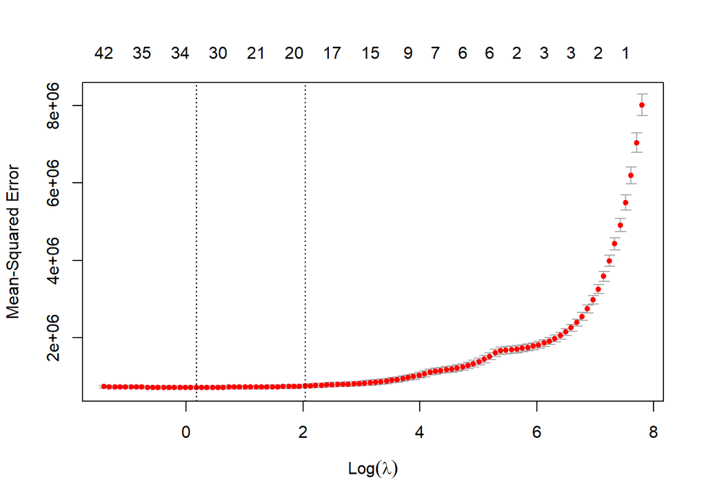

```r
plot(cv_fit0)
```

```r
coef(cv_fit0,s='lambda.1se')
```

```
## 49 x 1 sparse Matrix of class "dgCMatrix"
##                              1
## (Intercept)       1.158039e+03
## lag48_0tüketim   -1.119997e-01
## lag48_1tüketim   -4.027179e-02
## lag48_2tüketim    .
## lag48_3tüketim    .
## lag48_4tüketim    .
## lag48_5tüketim    .
## lag48_6tüketim    .
## lag48_7tüketim    1.563523e-01
## lag48_8tüketim    .
## lag48_9tüketim   -4.844012e-01
## lag48_10tüketim  -1.472035e-01
## lag48_11tüketim   .
## lag48_12tüketim   .
## lag48_13tüketim   2.128854e-01
## lag48_14tüketim   .
## lag48_15tüketim   .
## lag48_16tüketim   1.577678e-03
## lag48_17tüketim   3.049669e-02
## lag48_18tüketim   .
## lag48_19tüketim   .
## lag48_20tüketim   .
## lag48_21tüketim   3.017489e-02
## lag48_22tüketim   3.004807e-01
## lag48_23tüketim   9.546776e-01
## lag168_0tüketim   8.170101e-02
## lag168_1tüketim   .
## lag168_2tüketim   .
## lag168_3tüketim   .
## lag168_4tüketim   .
## lag168_5tüketim   .
## lag168_6tüketim   1.187969e-01
## lag168_7tüketim   1.997824e-01
## lag168_8tüketim   .
## lag168_9tüketim   .
## lag168_10tüketim  .
## lag168_11tüketim  1.965828e-02
## lag168_12tüketim  4.559783e-02
## lag168_13tüketim  .
## lag168_14tüketim  7.108353e-03
## lag168_15tüketim  .
## lag168_16tüketim  .
## lag168_17tüketim  .
## lag168_18tüketim  .
## lag168_19tüketim -1.421232e-01
## lag168_20tüketim -2.037003e-01
## lag168_21tüketim  .
## lag168_22tüketim -3.332446e-02
## lag168_23tüketim  .
```

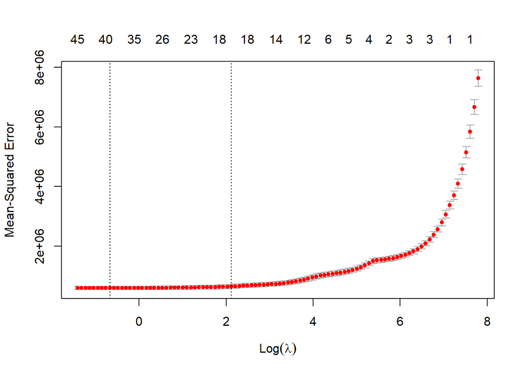

```r
plot(cv_fit1)
```

```r
coef(cv_fit1,s='lambda.1se')
```

```
## 49 x 1 sparse Matrix of class "dgCMatrix"
##                              1
## (Intercept)       2.003659e+03
## lag48_0tüketim   -1.672439e-01
## lag48_1tüketim    .
## lag48_2tüketim    .
## lag48_3tüketim    .
## lag48_4tüketim    .
## lag48_5tüketim    .
## lag48_6tüketim    1.034446e-01
## lag48_7tüketim    .
## lag48_8tüketim   -2.512550e-01
## lag48_9tüketim   -2.855170e-01
## lag48_10tüketim  -2.257256e-02
## lag48_11tüketim   .
## lag48_12tüketim   1.891197e-01
## lag48_13tüketim   .
## lag48_14tüketim   .
## lag48_15tüketim   4.772919e-02
## lag48_16tüketim   .
## lag48_17tüketim   .
## lag48_18tüketim   .
## lag48_19tüketim   .
## lag48_20tüketim   .
## lag48_21tüketim   .
## lag48_22tüketim   .
## lag48_23tüketim   1.347041e+00
## lag168_0tüketim   .
## lag168_1tüketim   .
## lag168_2tüketim   .
## lag168_3tüketim   1.775191e-02
## lag168_4tüketim   5.984408e-02
## lag168_5tüketim   1.313145e-01
## lag168_6tüketim   8.957178e-02
## lag168_7tüketim   6.436310e-02
## lag168_8tüketim   .
## lag168_9tüketim   4.298242e-03
## lag168_10tüketim  4.495037e-02
## lag168_11tüketim  .
## lag168_12tüketim  .
## lag168_13tüketim  3.823155e-02
## lag168_14tüketim  .
## lag168_15tüketim  .
## lag168_16tüketim  .
## lag168_17tüketim  .
## lag168_18tüketim -1.489198e-01
## lag168_19tüketim -9.664078e-02
## lag168_20tüketim  .
## lag168_21tüketim  .
## lag168_22tüketim  .
## lag168_23tüketim -1.872041e-01
```

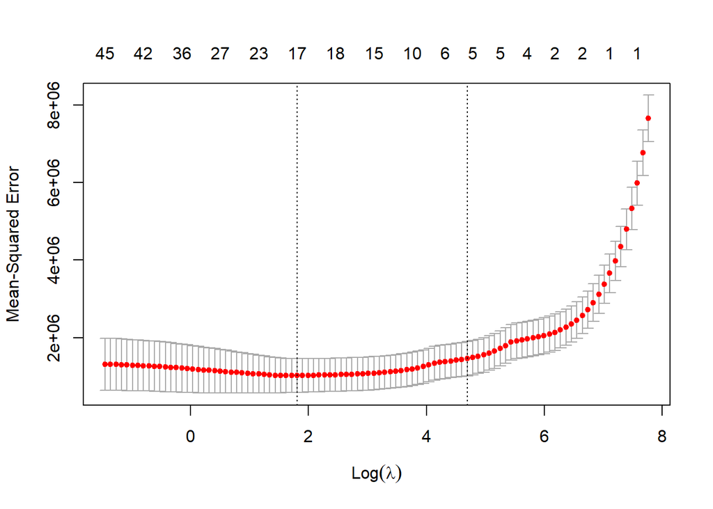

```r
plot(cv_fit2)
```

```r
coef(cv_fit2,s='lambda.1se')
```

```
## 49 x 1 sparse Matrix of class "dgCMatrix"
##                              1
## (Intercept)      1762.15228176
## lag48_0tüketim      .
## lag48_1tüketim      .
## lag48_2tüketim      .
## lag48_3tüketim      .
## lag48_4tüketim      .
## lag48_5tüketim      .
## lag48_6tüketim      .
## lag48_7tüketim     -0.13832956
## lag48_8tüketim      .
## lag48_9tüketim      .
## lag48_10tüketim     .
## lag48_11tüketim     .
## lag48_12tüketim     .
## lag48_13tüketim     .
## lag48_14tüketim     .
## lag48_15tüketim     .
## lag48_16tüketim     .
## lag48_17tüketim     .
## lag48_18tüketim     .
## lag48_19tüketim     .
## lag48_20tüketim     .
## lag48_21tüketim     .
## lag48_22tüketim     .
## lag48_23tüketim     0.91594633
## lag168_0tüketim     .
## lag168_1tüketim     .
## lag168_2tüketim     0.04987596
## lag168_3tüketim     .
## lag168_4tüketim     .
## lag168_5tüketim     0.04668083
## lag168_6tüketim     0.05190845
## lag168_7tüketim     .
## lag168_8tüketim     .
## lag168_9tüketim     .
## lag168_10tüketim    .
## lag168_11tüketim    .
## lag168_12tüketim    .
## lag168_13tüketim    .
## lag168_14tüketim    .
## lag168_15tüketim    .
## lag168_16tüketim    .
## lag168_17tüketim    .
## lag168_18tüketim    .
## lag168_19tüketim    .
## lag168_20tüketim    .
## lag168_21tüketim    .
## lag168_22tüketim    .
## lag168_23tüketim    .
```

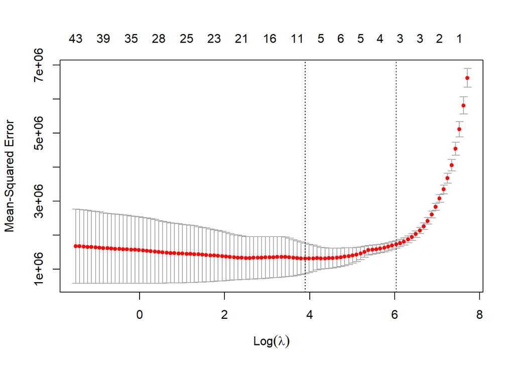

```r
plot(cv_fit3)
```

```r
coef(cv_fit3,s='lambda.1se')
```

```
## 49 x 1 sparse Matrix of class "dgCMatrix"
##                             1
## (Intercept)      6551.1958971
## lag48_0tüketim      .
## lag48_1tüketim      .
## lag48_2tüketim      .
## lag48_3tüketim      .
## lag48_4tüketim      .
## lag48_5tüketim      .
## lag48_6tüketim      .
## lag48_7tüketim      .
## lag48_8tüketim      .
## lag48_9tüketim      .
## lag48_10tüketim     .
## lag48_11tüketim     .
## lag48_12tüketim     .
## lag48_13tüketim     .
## lag48_14tüketim     .
## lag48_15tüketim     .
## lag48_16tüketim     .
## lag48_17tüketim     .
## lag48_18tüketim     .
## lag48_19tüketim     .
## lag48_20tüketim     .
## lag48_21tüketim     .
## lag48_22tüketim     0.4021512
## lag48_23tüketim     0.1578985
## lag168_0tüketim     .
## lag168_1tüketim     0.1740261
## lag168_2tüketim     .
## lag168_3tüketim     .
## lag168_4tüketim     .
## lag168_5tüketim     .
## lag168_6tüketim     .
## lag168_7tüketim     .
## lag168_8tüketim     .
## lag168_9tüketim     .
## lag168_10tüketim    .
## lag168_11tüketim    .
## lag168_12tüketim    .
## lag168_13tüketim    .
## lag168_14tüketim    .
## lag168_15tüketim    .
## lag168_16tüketim    .
## lag168_17tüketim    .
## lag168_18tüketim    .
## lag168_19tüketim    .
## lag168_20tüketim    .
## lag168_21tüketim    .
## lag168_22tüketim    .
## lag168_23tüketim    .
```

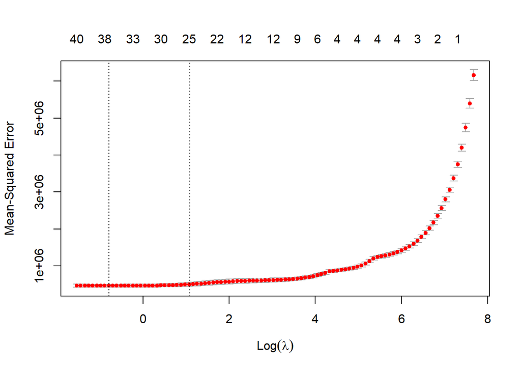

```r
plot(cv_fit4)
```

```r
coef(cv_fit4,s='lambda.1se')
```

```
## 49 x 1 sparse Matrix of class "dgCMatrix"
##                              1
## (Intercept)       2.081164e+03
## lag48_0tüketim   -3.587694e-01
## lag48_1tüketim    9.854819e-02
## lag48_2tüketim    1.397243e-01
## lag48_3tüketim    1.090665e-01
## lag48_4tüketim   -1.529809e-02
## lag48_5tüketim   -3.887653e-01
## lag48_6tüketim    .
## lag48_7tüketim   -1.051484e-01
## lag48_8tüketim    .
## lag48_9tüketim    3.821367e-01
## lag48_10tüketim  -1.457403e-01
## lag48_11tüketim   .
## lag48_12tüketim   .
## lag48_13tüketim   .
## lag48_14tüketim   .
## lag48_15tüketim  -3.302224e-01
## lag48_16tüketim   3.235338e-01
## lag48_17tüketim   .
## lag48_18tüketim  -4.725906e-02
## lag48_19tüketim   .
## lag48_20tüketim   .
## lag48_21tüketim  -9.872719e-02
## lag48_22tüketim   .
## lag48_23tüketim   1.471935e+00
## lag168_0tüketim  -8.779718e-02
## lag168_1tüketim   .
## lag168_2tüketim   8.103632e-02
## lag168_3tüketim   2.194041e-01
## lag168_4tüketim   9.520115e-04
## lag168_5tüketim   .
## lag168_6tüketim   2.613622e-02
## lag168_7tüketim   .
## lag168_8tüketim   .
## lag168_9tüketim   .
## lag168_10tüketim  2.967411e-02
## lag168_11tüketim  .
## lag168_12tüketim  .
## lag168_13tüketim  .
## lag168_14tüketim  3.107729e-02
## lag168_15tüketim  .
## lag168_16tüketim  .
## lag168_17tüketim -4.474623e-02
## lag168_18tüketim  .
## lag168_19tüketim  .
## lag168_20tüketim -1.507857e-01
## lag168_21tüketim  .
## lag168_22tüketim -1.142956e-02
## lag168_23tüketim -1.289537e-01
```

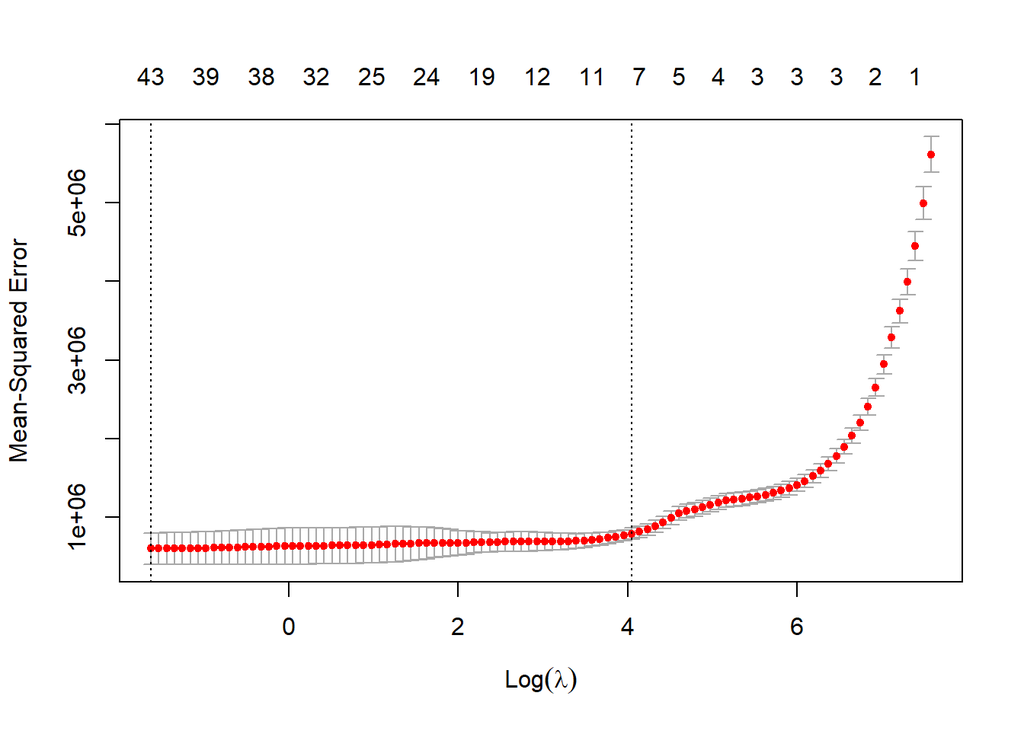

```r
plot(cv_fit5)
```

```r
coef(cv_fit5,s='lambda.1se')
```

```
## 49 x 1 sparse Matrix of class "dgCMatrix"
##                              1
## (Intercept)      2215.25840922
## lag48_0tüketim      .
## lag48_1tüketim      .
## lag48_2tüketim      .
## lag48_3tüketim      .
## lag48_4tüketim     -0.15182517
## lag48_5tüketim      .
## lag48_6tüketim      .
## lag48_7tüketim      .
## lag48_8tüketim      .
## lag48_9tüketim      .
## lag48_10tüketim     .
## lag48_11tüketim     .
## lag48_12tüketim     .
## lag48_13tüketim     .
## lag48_14tüketim     .
## lag48_15tüketim     0.01702501
## lag48_16tüketim     .
## lag48_17tüketim     .
## lag48_18tüketim     .
## lag48_19tüketim     .
## lag48_20tüketim     .
## lag48_21tüketim     .
## lag48_22tüketim     .
## lag48_23tüketim     0.93060147
## lag168_0tüketim     .
## lag168_1tüketim     .
## lag168_2tüketim     0.27529352
## lag168_3tüketim     0.06620771
## lag168_4tüketim     .
## lag168_5tüketim     .
## lag168_6tüketim     .
## lag168_7tüketim     .
## lag168_8tüketim     .
## lag168_9tüketim     .
## lag168_10tüketim    .
## lag168_11tüketim    .
## lag168_12tüketim    .
## lag168_13tüketim    .
## lag168_14tüketim    .
## lag168_15tüketim    .
## lag168_16tüketim    .
## lag168_17tüketim    .
## lag168_18tüketim    .
## lag168_19tüketim    .
## lag168_20tüketim    .
## lag168_21tüketim   -0.03719196
## lag168_22tüketim   -0.17405583
## lag168_23tüketim    .
```

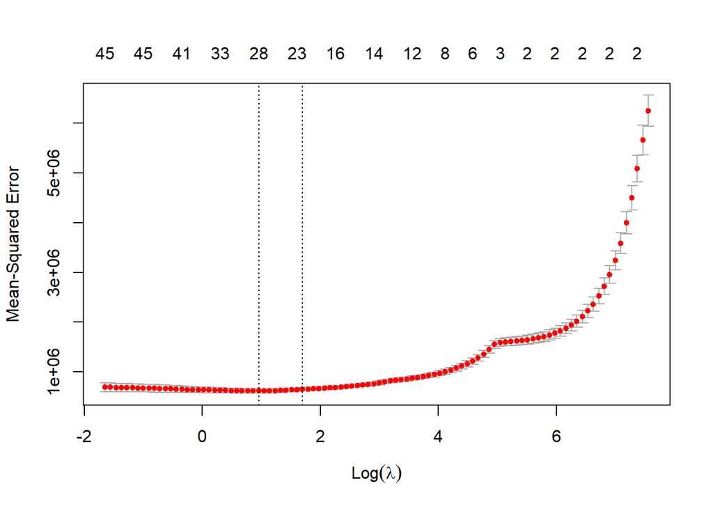

```r
plot(cv_fit6)
```

```r
coef(cv_fit6,s='lambda.1se')
```

```
## 49 x 1 sparse Matrix of class "dgCMatrix"
##                              1
## (Intercept)       2.034604e+03
## lag48_0tüketim    4.372124e-02
## lag48_1tüketim    .
## lag48_2tüketim   -2.579642e-01
## lag48_3tüketim   -5.080460e-02
## lag48_4tüketim    .
## lag48_5tüketim    .
## lag48_6tüketim    2.243263e-02
## lag48_7tüketim    3.166163e-01
## lag48_8tüketim   -1.079312e-01
## lag48_9tüketim   -2.410847e-01
## lag48_10tüketim   .
## lag48_11tüketim   .
## lag48_12tüketim   1.224276e-04
## lag48_13tüketim   .
## lag48_14tüketim   .
## lag48_15tüketim   3.491393e-02
## lag48_16tüketim  -6.288223e-02
## lag48_17tüketim   .
## lag48_18tüketim   .
## lag48_19tüketim   .
## lag48_20tüketim   .
## lag48_21tüketim   .
## lag48_22tüketim   3.878218e-03
## lag48_23tüketim   1.363497e+00
## lag168_0tüketim  -4.172501e-01
## lag168_1tüketim   5.426638e-01
## lag168_2tüketim   1.508375e-01
## lag168_3tüketim   .
## lag168_4tüketim   .
## lag168_5tüketim  -1.338578e-02
## lag168_6tüketim  -7.388988e-02
## lag168_7tüketim  -2.816283e-02
## lag168_8tüketim   .
## lag168_9tüketim   .
## lag168_10tüketim  .
## lag168_11tüketim  8.242557e-02
## lag168_12tüketim  1.929451e-01
## lag168_13tüketim  1.803550e-02
## lag168_14tüketim -2.563917e-01
## lag168_15tüketim  .
## lag168_16tüketim  .
## lag168_17tüketim  .
## lag168_18tüketim  .
## lag168_19tüketim  .
## lag168_20tüketim  .
## lag168_21tüketim -1.804307e-01
## lag168_22tüketim -1.030855e-01
## lag168_23tüketim  .
```

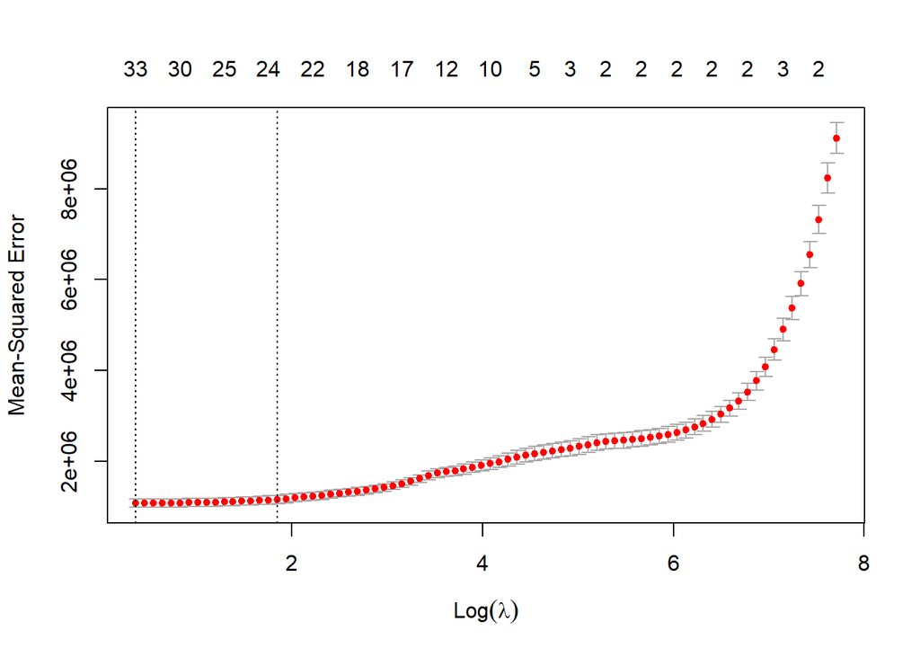

```r
plot(cv_fit7)
```

```r
coef(cv_fit7,s='lambda.1se')
```

```
## 49 x 1 sparse Matrix of class "dgCMatrix"
##                              1
## (Intercept)       1.982373e+03
## lag48_0tüketim    .
## lag48_1tüketim   -2.025126e-01
## lag48_2tüketim   -1.406381e-01
## lag48_3tüketim    .
## lag48_4tüketim    .
## lag48_5tüketim    .
## lag48_6tüketim    9.650185e-01
## lag48_7tüketim   -4.979168e-01
## lag48_8tüketim   -5.223163e-02
## lag48_9tüketim   -3.329009e-01
## lag48_10tüketim  -2.592497e-02
## lag48_11tüketim   .
## lag48_12tüketim   .
## lag48_13tüketim   2.751449e-01
## lag48_14tüketim   5.139287e-05
## lag48_15tüketim  -1.980164e-01
## lag48_16tüketim   .
## lag48_17tüketim   .
## lag48_18tüketim   .
## lag48_19tüketim   .
## lag48_20tüketim   .
## lag48_21tüketim   6.194471e-01
## lag48_22tüketim   .
## lag48_23tüketim   6.924178e-01
## lag168_0tüketim  -1.464733e-01
## lag168_1tüketim   5.364272e-01
## lag168_2tüketim   .
## lag168_3tüketim   .
## lag168_4tüketim   .
## lag168_5tüketim  -1.813385e-01
## lag168_6tüketim  -9.975938e-02
## lag168_7tüketim   .
## lag168_8tüketim   .
## lag168_9tüketim   7.915384e-02
## lag168_10tüketim  3.836379e-01
## lag168_11tüketim  .
## lag168_12tüketim -2.838000e-01
## lag168_13tüketim  .
## lag168_14tüketim  .
## lag168_15tüketim -2.264577e-01
## lag168_16tüketim  .
## lag168_17tüketim  .
## lag168_18tüketim  .
## lag168_19tüketim  .
## lag168_20tüketim -2.454017e-02
## lag168_21tüketim  .
## lag168_22tüketim -6.081958e-01
## lag168_23tüketim  4.822462e-01
```

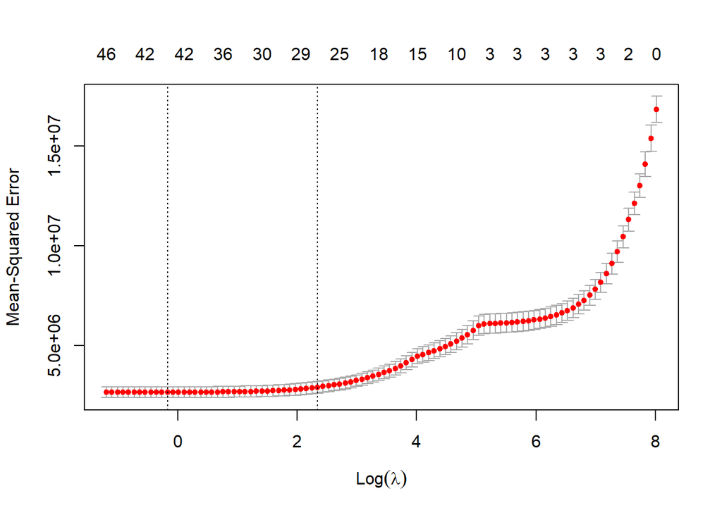

```r
plot(cv_fit8)
```

```r
coef(cv_fit8,s='lambda.1se')
```

```
## 49 x 1 sparse Matrix of class "dgCMatrix"
##                              1
## (Intercept)       4.239979e+03
## lag48_0tüketim   -1.409037e-01
## lag48_1tüketim   -1.682560e-01
## lag48_2tüketim    .
## lag48_3tüketim   -2.884095e-01
## lag48_4tüketim    .
## lag48_5tüketim    1.881192e+00
## lag48_6tüketim   -7.468580e-01
## lag48_7tüketim   -3.098488e-01
## lag48_8tüketim   -5.235926e-01
## lag48_9tüketim   -3.218303e-02
## lag48_10tüketim   .
## lag48_11tüketim   .
## lag48_12tüketim   3.752670e-01
## lag48_13tüketim   .
## lag48_14tüketim  -2.056303e-01
## lag48_15tüketim   .
## lag48_16tüketim   .
## lag48_17tüketim   .
## lag48_18tüketim   .
## lag48_19tüketim   .
## lag48_20tüketim   9.801432e-01
## lag48_21tüketim   1.996469e-01
## lag48_22tüketim   1.755243e-01
## lag48_23tüketim   1.585327e-01
## lag168_0tüketim   .
## lag168_1tüketim   9.113845e-01
## lag168_2tüketim   .
## lag168_3tüketim   .
## lag168_4tüketim  -7.598883e-01
## lag168_5tüketim  -2.429219e-02
## lag168_6tüketim   .
## lag168_7tüketim   .
## lag168_8tüketim   5.666252e-01
## lag168_9tüketim   1.780904e-01
## lag168_10tüketim  .
## lag168_11tüketim -2.824371e-01
## lag168_12tüketim  .
## lag168_13tüketim  .
## lag168_14tüketim -5.699098e-01
## lag168_15tüketim  .
## lag168_16tüketim -5.991475e-03
## lag168_17tüketim  .
## lag168_18tüketim  .
## lag168_19tüketim -1.544990e-01
## lag168_20tüketim -4.946219e-05
## lag168_21tüketim -4.724978e-01
## lag168_22tüketim  .
## lag168_23tüketim  3.039111e-01
```

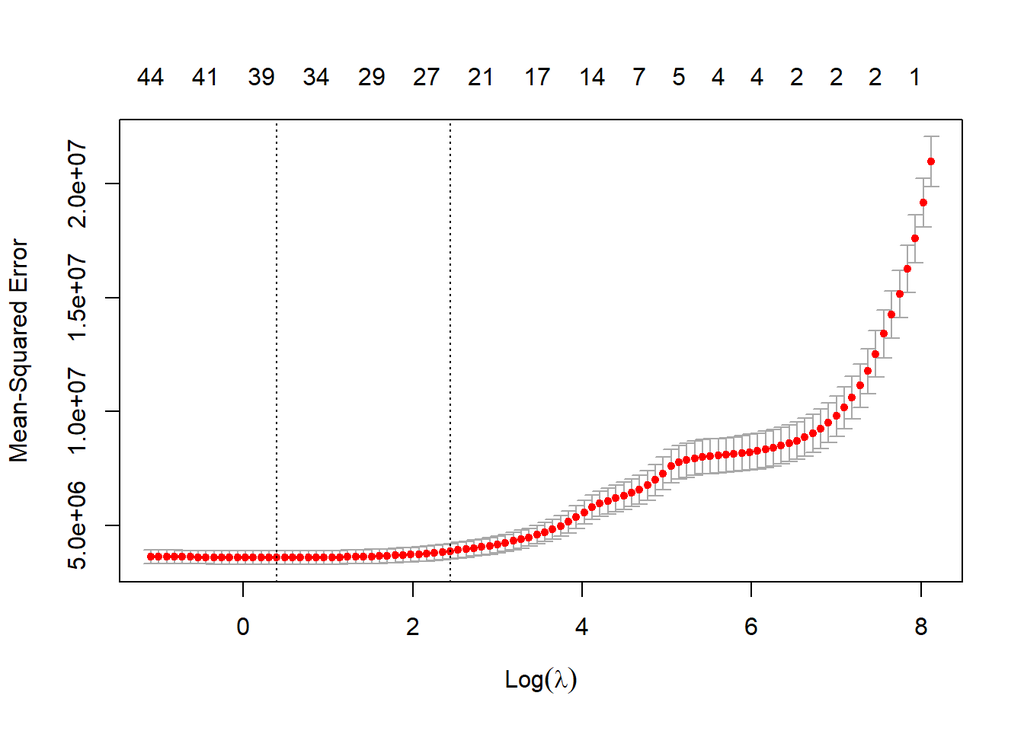

```r
plot(cv_fit9)
```

```r
coef(cv_fit9,s='lambda.1se')
```

```
## 49 x 1 sparse Matrix of class "dgCMatrix"
##                              1
## (Intercept)       5.308184e+03
## lag48_0tüketim   -4.485580e-01
## lag48_1tüketim    .
## lag48_2tüketim   -2.166856e-01
## lag48_3tüketim    .
## lag48_4tüketim    2.374860e+00
## lag48_5tüketim   -1.024122e+00
## lag48_6tüketim   -3.936459e-01
## lag48_7tüketim   -5.069190e-01
## lag48_8tüketim    .
## lag48_9tüketim    .
## lag48_10tüketim   .
## lag48_11tüketim   3.005032e-01
## lag48_12tüketim   .
## lag48_13tüketim  -2.279331e-01
## lag48_14tüketim   .
## lag48_15tüketim   .
## lag48_16tüketim   .
## lag48_17tüketim   .
## lag48_18tüketim   .
## lag48_19tüketim   1.018304e+00
## lag48_20tüketim   3.444936e-01
## lag48_21tüketim   9.291905e-02
## lag48_22tüketim   1.380456e-01
## lag48_23tüketim   .
## lag168_0tüketim   9.561445e-01
## lag168_1tüketim   .
## lag168_2tüketim   .
## lag168_3tüketim  -6.742669e-01
## lag168_4tüketim  -4.116548e-05
## lag168_5tüketim   .
## lag168_6tüketim   .
## lag168_7tüketim   5.145847e-01
## lag168_8tüketim   2.212855e-01
## lag168_9tüketim   .
## lag168_10tüketim -3.953515e-01
## lag168_11tüketim  .
## lag168_12tüketim  .
## lag168_13tüketim -5.458380e-01
## lag168_14tüketim  .
## lag168_15tüketim  .
## lag168_16tüketim  .
## lag168_17tüketim  .
## lag168_18tüketim -2.017925e-01
## lag168_19tüketim -4.352719e-05
## lag168_20tüketim -5.614900e-01
## lag168_21tüketim  .
## lag168_22tüketim  3.256617e-01
## lag168_23tüketim  .
```

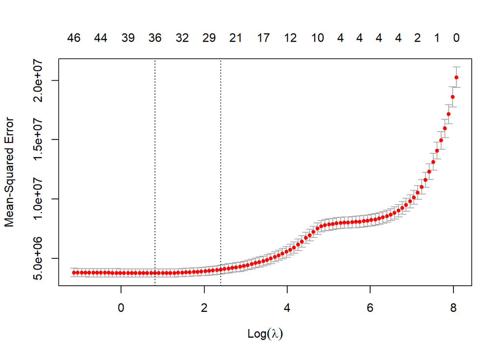

```r
plot(cv_fit10)
```

```r
coef(cv_fit10,s='lambda.1se')
```

```
## 49 x 1 sparse Matrix of class "dgCMatrix"
##                              1
## (Intercept)       6.528389e+03
## lag48_0tüketim   -6.509773e-01
## lag48_1tüketim   -2.031031e-01
## lag48_2tüketim    .
## lag48_3tüketim    2.700602e+00
## lag48_4tüketim   -1.087978e+00
## lag48_5tüketim   -2.233263e-01
## lag48_6tüketim   -6.852498e-01
## lag48_7tüketim   -5.131657e-05
## lag48_8tüketim    .
## lag48_9tüketim    .
## lag48_10tüketim   2.435134e-01
## lag48_11tüketim   .
## lag48_12tüketim  -2.459603e-01
## lag48_13tüketim   .
## lag48_14tüketim   .
## lag48_15tüketim   .
## lag48_16tüketim   .
## lag48_17tüketim   .
## lag48_18tüketim   8.755157e-01
## lag48_19tüketim   5.236882e-01
## lag48_20tüketim   .
## lag48_21tüketim   1.717301e-01
## lag48_22tüketim   .
## lag48_23tüketim   .
## lag168_0tüketim   9.022920e-01
## lag168_1tüketim   .
## lag168_2tüketim  -5.905835e-01
## lag168_3tüketim  -9.251937e-02
## lag168_4tüketim   .
## lag168_5tüketim   .
## lag168_6tüketim   3.778204e-01
## lag168_7tüketim   3.840587e-01
## lag168_8tüketim   .
## lag168_9tüketim  -5.176991e-01
## lag168_10tüketim  .
## lag168_11tüketim  .
## lag168_12tüketim -3.405596e-01
## lag168_13tüketim  .
## lag168_14tüketim -8.989238e-02
## lag168_15tüketim  .
## lag168_16tüketim  .
## lag168_17tüketim -1.443486e-01
## lag168_18tüketim  .
## lag168_19tüketim -6.267822e-01
## lag168_20tüketim  .
## lag168_21tüketim  4.221710e-01
## lag168_22tüketim  .
## lag168_23tüketim -2.617032e-02
```

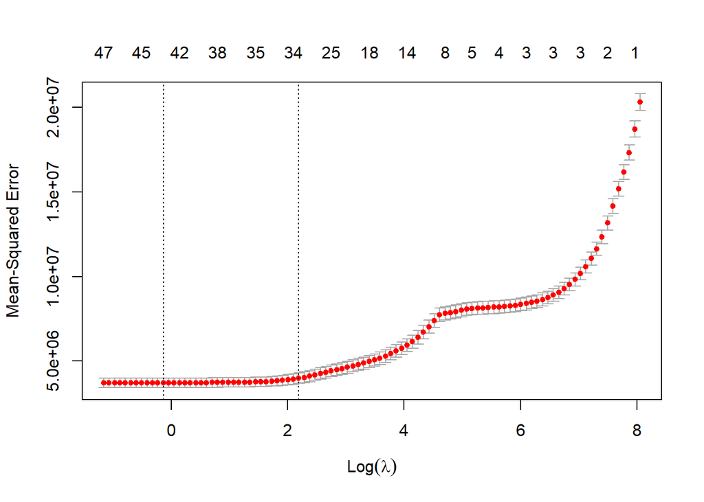

```r
plot(cv_fit11)
```

```r
coef(cv_fit11,s='lambda.1se')
```

```
## 49 x 1 sparse Matrix of class "dgCMatrix"
##                              1
## (Intercept)      7138.12800211
## lag48_0tüketim     -0.81889194
## lag48_1tüketim      .
## lag48_2tüketim      2.70796328
## lag48_3tüketim     -1.12559768
## lag48_4tüketim     -0.05425249
## lag48_5tüketim     -0.85321342
## lag48_6tüketim     -0.01812033
## lag48_7tüketim      .
## lag48_8tüketim      .
## lag48_9tüketim      0.38324971
## lag48_10tüketim     .
## lag48_11tüketim    -0.43734627
## lag48_12tüketim     .
## lag48_13tüketim     .
## lag48_14tüketim     .
## lag48_15tüketim    -0.01568108
## lag48_16tüketim     .
## lag48_17tüketim     0.92871915
## lag48_18tüketim     0.32443513
## lag48_19tüketim     0.08208501
## lag48_20tüketim     0.36572762
## lag48_21tüketim    -0.33147815
## lag48_22tüketim    -0.57261565
## lag48_23tüketim     0.85158514
## lag168_0tüketim     0.79163224
## lag168_1tüketim    -0.53490815
## lag168_2tüketim    -0.18159475
## lag168_3tüketim     .
## lag168_4tüketim     .
## lag168_5tüketim     0.50457987
## lag168_6tüketim     0.53646789
## lag168_7tüketim    -0.20580197
## lag168_8tüketim    -0.52785115
## lag168_9tüketim    -0.04205327
## lag168_10tüketim    .
## lag168_11tüketim   -0.29886485
## lag168_12tüketim    .
## lag168_13tüketim   -0.12130597
## lag168_14tüketim    .
## lag168_15tüketim   -0.01016917
## lag168_16tüketim   -0.03194772
## lag168_17tüketim    .
## lag168_18tüketim   -0.53879400
## lag168_19tüketim    .
## lag168_20tüketim    0.41559289
## lag168_21tüketim    0.26342968
## lag168_22tüketim    .
## lag168_23tüketim   -0.32931371
```

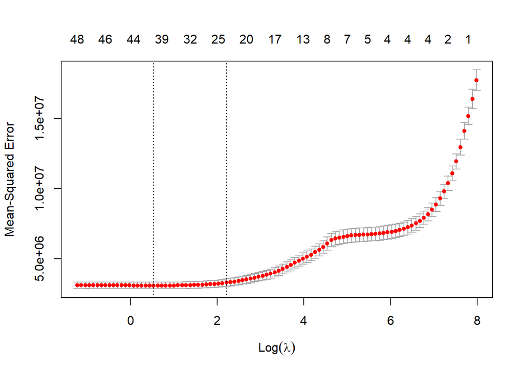

```r
plot(cv_fit12)
```

```r
coef(cv_fit12,s='lambda.1se')
```

```
## 49 x 1 sparse Matrix of class "dgCMatrix"
##                              1
## (Intercept)      3349.13581627
## lag48_0tüketim     -0.28513680
## lag48_1tüketim      1.98314491
## lag48_2tüketim     -0.91985745
## lag48_3tüketim     -0.15863257
## lag48_4tüketim     -0.83653491
## lag48_5tüketim     -0.03598310
## lag48_6tüketim      .
## lag48_7tüketim      .
## lag48_8tüketim      0.15125060
## lag48_9tüketim      0.17255840
## lag48_10tüketim    -0.11527887
## lag48_11tüketim     .
## lag48_12tüketim     .
## lag48_13tüketim     .
## lag48_14tüketim     .
## lag48_15tüketim     .
## lag48_16tüketim     0.60520759
## lag48_17tüketim     .
## lag48_18tüketim     .
## lag48_19tüketim     0.57499256
## lag48_20tüketim     .
## lag48_21tüketim    -1.40970127
## lag48_22tüketim     .
## lag48_23tüketim     1.47756474
## lag168_0tüketim     .
## lag168_1tüketim    -0.01061770
## lag168_2tüketim     .
## lag168_3tüketim     .
## lag168_4tüketim     0.51539666
## lag168_5tüketim     0.55201460
## lag168_6tüketim    -0.19616833
## lag168_7tüketim    -0.42135135
## lag168_8tüketim    -0.01025497
## lag168_9tüketim     .
## lag168_10tüketim   -0.41726515
## lag168_11tüketim    .
## lag168_12tüketim    .
## lag168_13tüketim    .
## lag168_14tüketim    .
## lag168_15tüketim    .
## lag168_16tüketim    .
## lag168_17tüketim   -0.20655043
## lag168_18tüketim    .
## lag168_19tüketim    0.21073807
## lag168_20tüketim    0.33936008
## lag168_21tüketim    .
## lag168_22tüketim    .
## lag168_23tüketim   -0.43866348
```

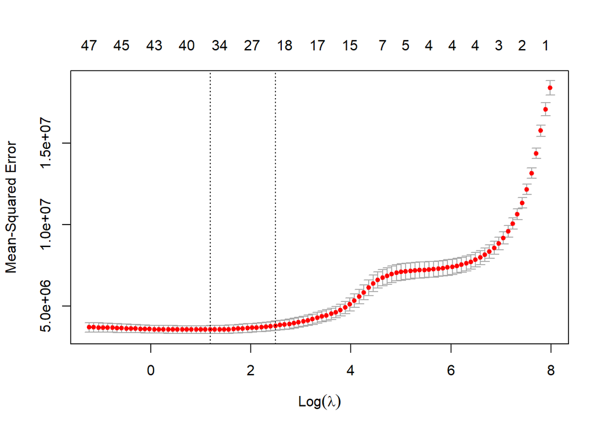

```r
plot(cv_fit13)
```

```r
coef(cv_fit13,s='lambda.1se')
```

```
## 49 x 1 sparse Matrix of class "dgCMatrix"
##                              1
## (Intercept)       4.095400e+03
## lag48_0tüketim    1.347839e+00
## lag48_1tüketim   -6.883110e-01
## lag48_2tüketim   -2.268633e-01
## lag48_3tüketim   -7.173730e-01
## lag48_4tüketim   -4.720664e-03
## lag48_5tüketim    .
## lag48_6tüketim    .
## lag48_7tüketim    1.075638e-01
## lag48_8tüketim    .
## lag48_9tüketim    .
## lag48_10tüketim  -6.264644e-02
## lag48_11tüketim   .
## lag48_12tüketim   .
## lag48_13tüketim   .
## lag48_14tüketim   .
## lag48_15tüketim   8.343486e-01
## lag48_16tüketim   .
## lag48_17tüketim   .
## lag48_18tüketim   5.767554e-01
## lag48_19tüketim   .
## lag48_20tüketim  -1.102089e+00
## lag48_21tüketim   .
## lag48_22tüketim   .
## lag48_23tüketim   1.286775e+00
## lag168_0tüketim   1.298394e-01
## lag168_1tüketim   .
## lag168_2tüketim   .
## lag168_3tüketim   6.043274e-01
## lag168_4tüketim   2.948560e-01
## lag168_5tüketim   .
## lag168_6tüketim  -5.805188e-01
## lag168_7tüketim   .
## lag168_8tüketim   .
## lag168_9tüketim  -5.916788e-02
## lag168_10tüketim  .
## lag168_11tüketim -4.500056e-01
## lag168_12tüketim  .
## lag168_13tüketim  .
## lag168_14tüketim  .
## lag168_15tüketim  .
## lag168_16tüketim  .
## lag168_17tüketim  .
## lag168_18tüketim  .
## lag168_19tüketim  3.632067e-01
## lag168_20tüketim  .
## lag168_21tüketim  .
## lag168_22tüketim  .
## lag168_23tüketim -4.925257e-01
```

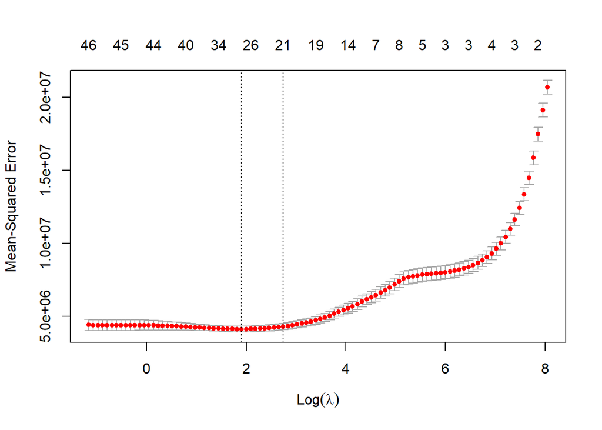

```r
plot(cv_fit14)
```

```r
coef(cv_fit14,s='lambda.1se')
```

```
## 49 x 1 sparse Matrix of class "dgCMatrix"
##                              1
## (Intercept)      5818.64176734
## lag48_0tüketim      0.26025493
## lag48_1tüketim      .
## lag48_2tüketim     -0.19985186
## lag48_3tüketim     -0.60741925
## lag48_4tüketim      .
## lag48_5tüketim      .
## lag48_6tüketim      0.09028193
## lag48_7tüketim      0.30641104
## lag48_8tüketim      .
## lag48_9tüketim      .
## lag48_10tüketim     .
## lag48_11tüketim     .
## lag48_12tüketim     .
## lag48_13tüketim     .
## lag48_14tüketim     0.29796368
## lag48_15tüketim     .
## lag48_16tüketim     0.21374724
## lag48_17tüketim     0.86265714
## lag48_18tüketim     .
## lag48_19tüketim    -1.43033197
## lag48_20tüketim     .
## lag48_21tüketim     .
## lag48_22tüketim     .
## lag48_23tüketim     1.47365228
## lag168_0tüketim     0.17332433
## lag168_1tüketim     .
## lag168_2tüketim     0.56779891
## lag168_3tüketim     0.51766763
## lag168_4tüketim     .
## lag168_5tüketim    -0.51744420
## lag168_6tüketim    -0.13870979
## lag168_7tüketim     .
## lag168_8tüketim     .
## lag168_9tüketim     .
## lag168_10tüketim   -0.33941860
## lag168_11tüketim   -0.30895750
## lag168_12tüketim   -0.01704193
## lag168_13tüketim    .
## lag168_14tüketim    .
## lag168_15tüketim    .
## lag168_16tüketim    .
## lag168_17tüketim    0.30862420
## lag168_18tüketim    .
## lag168_19tüketim    .
## lag168_20tüketim    .
## lag168_21tüketim    .
## lag168_22tüketim   -0.22585463
## lag168_23tüketim   -0.22087214
```

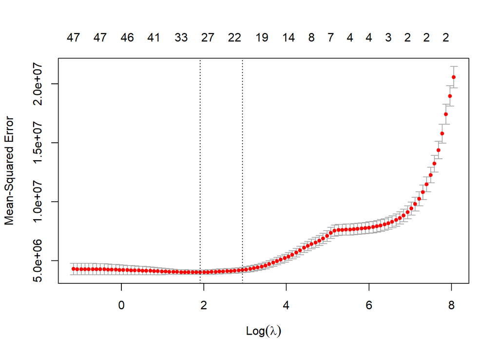

```r
plot(cv_fit15)
```

```r
coef(cv_fit15,s='lambda.1se')
```

```
## 49 x 1 sparse Matrix of class "dgCMatrix"
##                              1
## (Intercept)      5635.10739381
## lag48_0tüketim      .
## lag48_1tüketim      .
## lag48_2tüketim     -0.52474932
## lag48_3tüketim      .
## lag48_4tüketim      .
## lag48_5tüketim      0.18069547
## lag48_6tüketim      0.29652579
## lag48_7tüketim      .
## lag48_8tüketim      .
## lag48_9tüketim      .
## lag48_10tüketim     .
## lag48_11tüketim     .
## lag48_12tüketim     .
## lag48_13tüketim     0.25807925
## lag48_14tüketim     .
## lag48_15tüketim     0.19637595
## lag48_16tüketim     0.71954502
## lag48_17tüketim     .
## lag48_18tüketim    -1.38533385
## lag48_19tüketim    -0.04596541
## lag48_20tüketim     .
## lag48_21tüketim     .
## lag48_22tüketim     0.87476811
## lag48_23tüketim     0.60863693
## lag168_0tüketim     .
## lag168_1tüketim     0.81012582
## lag168_2tüketim     0.39186370
## lag168_3tüketim     .
## lag168_4tüketim    -0.46848939
## lag168_5tüketim    -0.22819577
## lag168_6tüketim     .
## lag168_7tüketim     .
## lag168_8tüketim     .
## lag168_9tüketim    -0.36172738
## lag168_10tüketim   -0.24474606
## lag168_11tüketim   -0.03894567
## lag168_12tüketim    .
## lag168_13tüketim    .
## lag168_14tüketim    .
## lag168_15tüketim    .
## lag168_16tüketim    0.36671230
## lag168_17tüketim    .
## lag168_18tüketim    .
## lag168_19tüketim    .
## lag168_20tüketim    .
## lag168_21tüketim    .
## lag168_22tüketim   -0.23654680
## lag168_23tüketim   -0.13142547
```

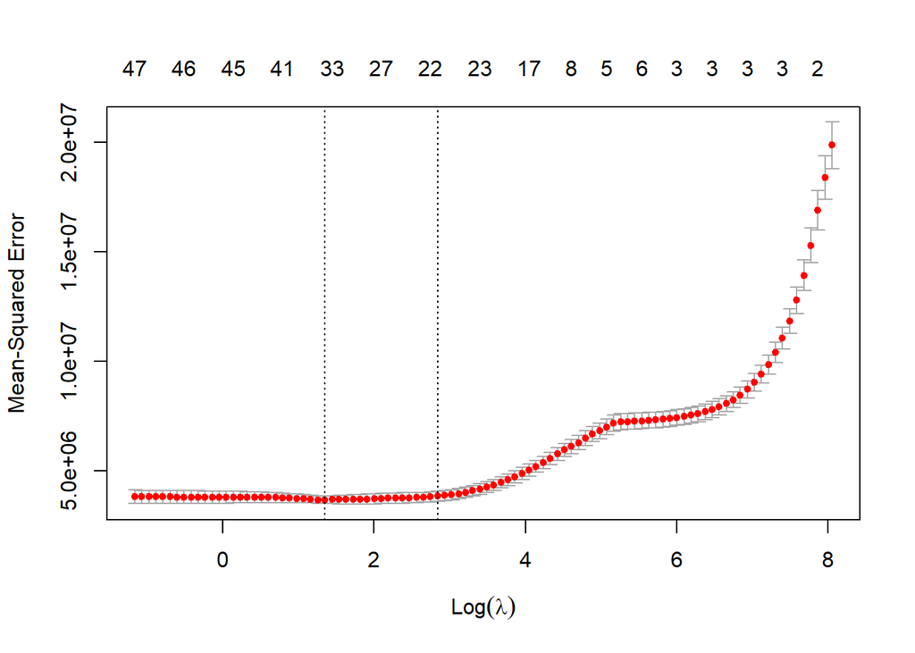

```r
plot(cv_fit16)
```

```r
coef(cv_fit16,s='lambda.1se')
```

```
## 49 x 1 sparse Matrix of class "dgCMatrix"
##                              1
## (Intercept)       6.333672e+03
## lag48_0tüketim   -6.912872e-03
## lag48_1tüketim   -5.181936e-01
## lag48_2tüketim    .
## lag48_3tüketim    .
## lag48_4tüketim    3.143396e-01
## lag48_5tüketim    2.323620e-01
## lag48_6tüketim    .
## lag48_7tüketim    .
## lag48_8tüketim    .
## lag48_9tüketim    .
## lag48_10tüketim   .
## lag48_11tüketim   .
## lag48_12tüketim   1.603822e-01
## lag48_13tüketim   .
## lag48_14tüketim   2.899258e-01
## lag48_15tüketim   6.171445e-01
## lag48_16tüketim   .
## lag48_17tüketim  -1.233625e+00
## lag48_18tüketim  -2.523647e-01
## lag48_19tüketim   .
## lag48_20tüketim   .
## lag48_21tüketim   4.396861e-01
## lag48_22tüketim   .
## lag48_23tüketim   1.102927e+00
## lag168_0tüketim   5.306872e-01
## lag168_1tüketim   6.862565e-01
## lag168_2tüketim   .
## lag168_3tüketim  -4.726684e-01
## lag168_4tüketim  -3.730278e-01
## lag168_5tüketim   .
## lag168_6tüketim   .
## lag168_7tüketim   .
## lag168_8tüketim  -8.425122e-02
## lag168_9tüketim  -3.686665e-01
## lag168_10tüketim -2.727420e-03
## lag168_11tüketim -1.794941e-01
## lag168_12tüketim  .
## lag168_13tüketim  .
## lag168_14tüketim  .
## lag168_15tüketim  2.806898e-01
## lag168_16tüketim  2.109445e-01
## lag168_17tüketim  .
## lag168_18tüketim  .
## lag168_19tüketim  .
## lag168_20tüketim  .
## lag168_21tüketim -1.037208e-01
## lag168_22tüketim  .
## lag168_23tüketim -2.866497e-01
```

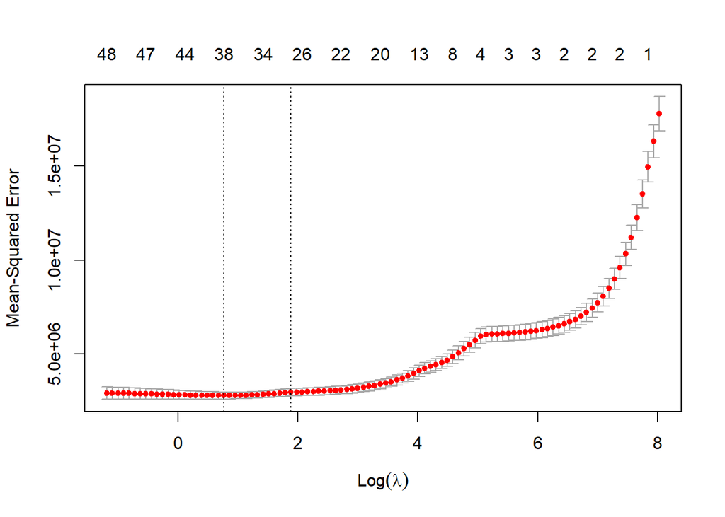

```r
plot(cv_fit17)
```

```r
coef(cv_fit17,s='lambda.1se')
```

```
## 49 x 1 sparse Matrix of class "dgCMatrix"
##                              1
## (Intercept)       6.980434e+03
## lag48_0tüketim   -5.366146e-01
## lag48_1tüketim    .
## lag48_2tüketim    .
## lag48_3tüketim    4.418890e-01
## lag48_4tüketim    1.069730e-01
## lag48_5tüketim    .
## lag48_6tüketim    .
## lag48_7tüketim    .
## lag48_8tüketim   -9.557867e-02
## lag48_9tüketim    .
## lag48_10tüketim   .
## lag48_11tüketim   3.009117e-01
## lag48_12tüketim   8.750571e-03
## lag48_13tüketim   2.480307e-01
## lag48_14tüketim   7.031527e-01
## lag48_15tüketim  -5.082112e-03
## lag48_16tüketim  -1.342515e+00
## lag48_17tüketim  -1.823215e-01
## lag48_18tüketim  -3.765576e-02
## lag48_19tüketim   .
## lag48_20tüketim   4.262103e-01
## lag48_21tüketim  -1.507149e-03
## lag48_22tüketim   .
## lag48_23tüketim   1.154690e+00
## lag168_0tüketim   1.216997e+00
## lag168_1tüketim  -1.580394e-02
## lag168_2tüketim  -4.807261e-01
## lag168_3tüketim  -5.167859e-01
## lag168_4tüketim   .
## lag168_5tüketim   .
## lag168_6tüketim   .
## lag168_7tüketim  -3.928323e-02
## lag168_8tüketim  -2.928298e-01
## lag168_9tüketim  -2.423622e-03
## lag168_10tüketim -3.220271e-01
## lag168_11tüketim -4.773931e-05
## lag168_12tüketim -1.179771e-02
## lag168_13tüketim  1.072074e-01
## lag168_14tüketim  3.811506e-01
## lag168_15tüketim  1.549926e-01
## lag168_16tüketim  .
## lag168_17tüketim  .
## lag168_18tüketim  .
## lag168_19tüketim  .
## lag168_20tüketim -5.050208e-02
## lag168_21tüketim  .
## lag168_22tüketim  .
## lag168_23tüketim -3.095111e-01
```

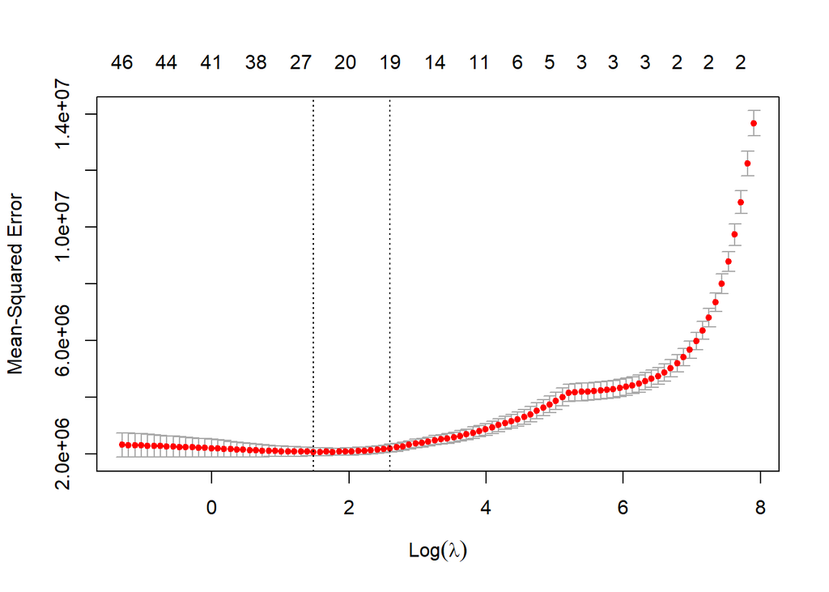

```r
plot(cv_fit18)
```

```r
coef(cv_fit18,s='lambda.1se')
```

```
## 49 x 1 sparse Matrix of class "dgCMatrix"
##                              1
## (Intercept)      5079.91505464
## lag48_0tüketim     -0.26705129
## lag48_1tüketim      .
## lag48_2tüketim      .
## lag48_3tüketim      0.14838858
## lag48_4tüketim      .
## lag48_5tüketim      .
## lag48_6tüketim      .
## lag48_7tüketim      .
## lag48_8tüketim      .
## lag48_9tüketim      .
## lag48_10tüketim     0.21518948
## lag48_11tüketim     .
## lag48_12tüketim     0.10384997
## lag48_13tüketim     0.44891338
## lag48_14tüketim     .
## lag48_15tüketim    -1.18475796
## lag48_16tüketim     .
## lag48_17tüketim     .
## lag48_18tüketim     .
## lag48_19tüketim     0.28669018
## lag48_20tüketim     .
## lag48_21tüketim     .
## lag48_22tüketim     .
## lag48_23tüketim     1.13857693
## lag168_0tüketim     0.68821727
## lag168_1tüketim     .
## lag168_2tüketim    -0.14731356
## lag168_3tüketim     .
## lag168_4tüketim     .
## lag168_5tüketim     .
## lag168_6tüketim    -0.17202662
## lag168_7tüketim    -0.08743218
## lag168_8tüketim    -0.01863045
## lag168_9tüketim    -0.30140475
## lag168_10tüketim    .
## lag168_11tüketim    .
## lag168_12tüketim    .
## lag168_13tüketim    0.22079401
## lag168_14tüketim    0.21974552
## lag168_15tüketim    .
## lag168_16tüketim    .
## lag168_17tüketim    0.01903293
## lag168_18tüketim    .
## lag168_19tüketim    .
## lag168_20tüketim    0.07580242
## lag168_21tüketim    .
## lag168_22tüketim    .
## lag168_23tüketim   -0.44048490
```

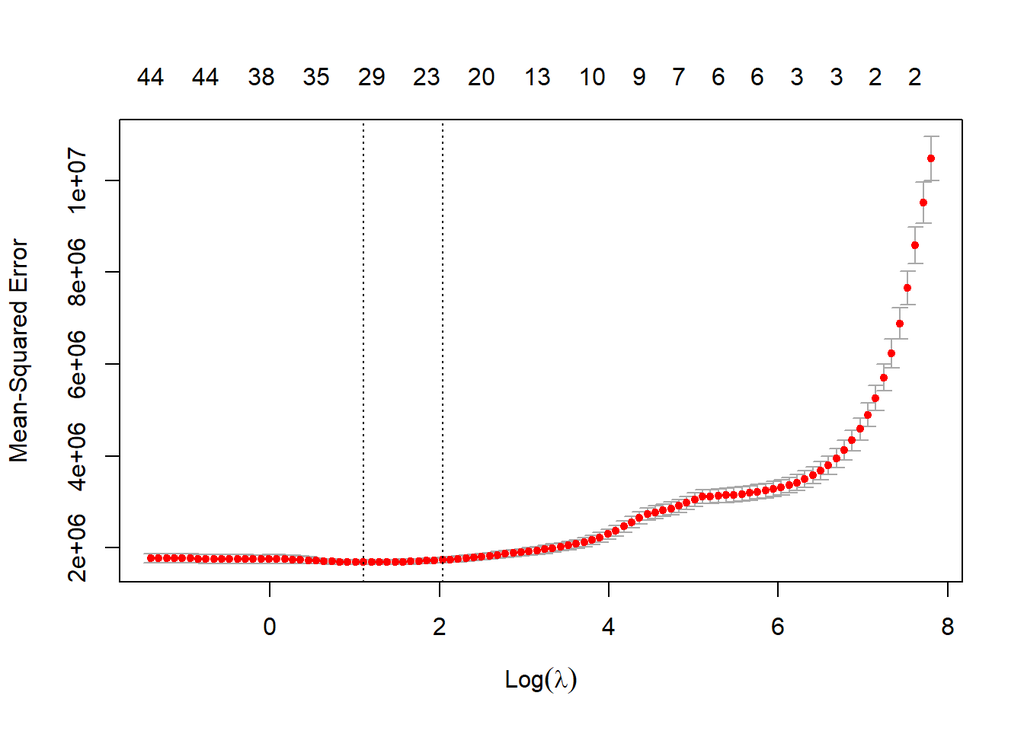

```r
plot(cv_fit19)
```

```r
coef(cv_fit19,s='lambda.1se')
```

```
## 49 x 1 sparse Matrix of class "dgCMatrix"
##                              1
## (Intercept)       4.033993e+03
## lag48_0tüketim   -2.356848e-01
## lag48_1tüketim    8.914085e-02
## lag48_2tüketim    6.337530e-03
## lag48_3tüketim    .
## lag48_4tüketim    .
## lag48_5tüketim    .
## lag48_6tüketim    .
## lag48_7tüketim   -3.670890e-02
## lag48_8tüketim    .
## lag48_9tüketim    .
## lag48_10tüketim   1.358641e-01
## lag48_11tüketim   2.501421e-01
## lag48_12tüketim   2.786167e-01
## lag48_13tüketim   .
## lag48_14tüketim  -8.210136e-01
## lag48_15tüketim  -1.696985e-01
## lag48_16tüketim  -3.934955e-02
## lag48_17tüketim   .
## lag48_18tüketim   4.034415e-01
## lag48_19tüketim   .
## lag48_20tüketim   .
## lag48_21tüketim   5.572397e-03
## lag48_22tüketim   .
## lag48_23tüketim   1.063986e+00
## lag168_0tüketim   4.823188e-01
## lag168_1tüketim   .
## lag168_2tüketim   .
## lag168_3tüketim  -5.393001e-02
## lag168_4tüketim   .
## lag168_5tüketim  -2.530203e-02
## lag168_6tüketim   .
## lag168_7tüketim  -9.472409e-02
## lag168_8tüketim  -7.707927e-02
## lag168_9tüketim   .
## lag168_10tüketim  .
## lag168_11tüketim  2.064324e-03
## lag168_12tüketim  3.655832e-01
## lag168_13tüketim  1.048666e-01
## lag168_14tüketim  .
## lag168_15tüketim  .
## lag168_16tüketim  .
## lag168_17tüketim  .
## lag168_18tüketim  .
## lag168_19tüketim  6.571597e-02
## lag168_20tüketim  1.084402e-01
## lag168_21tüketim  .
## lag168_22tüketim  .
## lag168_23tüketim -7.586748e-01
```

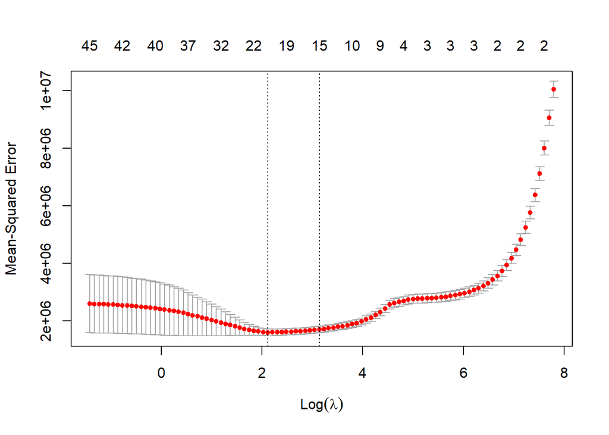

```r
plot(cv_fit20)
```

```r
coef(cv_fit20,s='lambda.1se')
```

```
## 49 x 1 sparse Matrix of class "dgCMatrix"
##                              1
## (Intercept)       2.501651e+03
## lag48_0tüketim    .
## lag48_1tüketim    1.313322e-01
## lag48_2tüketim    .
## lag48_3tüketim    .
## lag48_4tüketim    .
## lag48_5tüketim    .
## lag48_6tüketim   -6.465675e-02
## lag48_7tüketim   -1.692910e-03
## lag48_8tüketim    .
## lag48_9tüketim    .
## lag48_10tüketim   .
## lag48_11tüketim   .
## lag48_12tüketim   .
## lag48_13tüketim  -5.098991e-01
## lag48_14tüketim   .
## lag48_15tüketim   .
## lag48_16tüketim   .
## lag48_17tüketim   1.352475e-01
## lag48_18tüketim   .
## lag48_19tüketim   .
## lag48_20tüketim   9.108908e-02
## lag48_21tüketim   .
## lag48_22tüketim   .
## lag48_23tüketim   9.753449e-01
## lag168_0tüketim   1.670182e-01
## lag168_1tüketim   3.034604e-01
## lag168_2tüketim   .
## lag168_3tüketim   .
## lag168_4tüketim   .
## lag168_5tüketim   .
## lag168_6tüketim  -4.405723e-02
## lag168_7tüketim   .
## lag168_8tüketim   .
## lag168_9tüketim   .
## lag168_10tüketim  .
## lag168_11tüketim  3.255495e-02
## lag168_12tüketim  2.679448e-01
## lag168_13tüketim  .
## lag168_14tüketim  .
## lag168_15tüketim  .
## lag168_16tüketim  .
## lag168_17tüketim  .
## lag168_18tüketim  2.353532e-03
## lag168_19tüketim  .
## lag168_20tüketim  .
## lag168_21tüketim  .
## lag168_22tüketim -1.404001e-02
## lag168_23tüketim -5.395049e-01
```

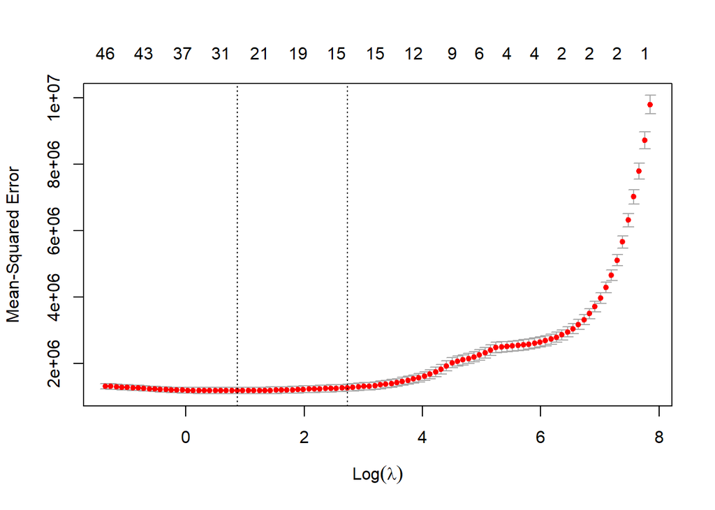

```r
plot(cv_fit21)
```

```r
coef(cv_fit21,s='lambda.1se')
```

```
## 49 x 1 sparse Matrix of class "dgCMatrix"
##                              1
## (Intercept)       3.700323e+03
## lag48_0tüketim    .
## lag48_1tüketim    .
## lag48_2tüketim    .
## lag48_3tüketim    6.801761e-03
## lag48_4tüketim    .
## lag48_5tüketim    6.698710e-03
## lag48_6tüketim    6.357283e-02
## lag48_7tüketim    .
## lag48_8tüketim   -1.008030e-01
## lag48_9tüketim    .
## lag48_10tüketim   .
## lag48_11tüketim   .
## lag48_12tüketim  -5.481074e-01
## lag48_13tüketim   .
## lag48_14tüketim   .
## lag48_15tüketim   .
## lag48_16tüketim   6.392035e-02
## lag48_17tüketim   .
## lag48_18tüketim   .
## lag48_19tüketim   2.012477e-02
## lag48_20tüketim   1.440345e-01
## lag48_21tüketim   .
## lag48_22tüketim   .
## lag48_23tüketim   1.189154e+00
## lag168_0tüketim   1.821620e-01
## lag168_1tüketim   .
## lag168_2tüketim   9.298153e-02
## lag168_3tüketim   .
## lag168_4tüketim   .
## lag168_5tüketim   .
## lag168_6tüketim   .
## lag168_7tüketim   .
## lag168_8tüketim  -1.337508e-01
## lag168_9tüketim   .
## lag168_10tüketim  4.354772e-01
## lag168_11tüketim  .
## lag168_12tüketim  .
## lag168_13tüketim  .
## lag168_14tüketim  1.014592e-03
## lag168_15tüketim  .
## lag168_16tüketim  .
## lag168_17tüketim  1.042068e-01
## lag168_18tüketim  .
## lag168_19tüketim  .
## lag168_20tüketim  .
## lag168_21tüketim  .
## lag168_22tüketim -3.210354e-01
## lag168_23tüketim -2.864157e-01
```

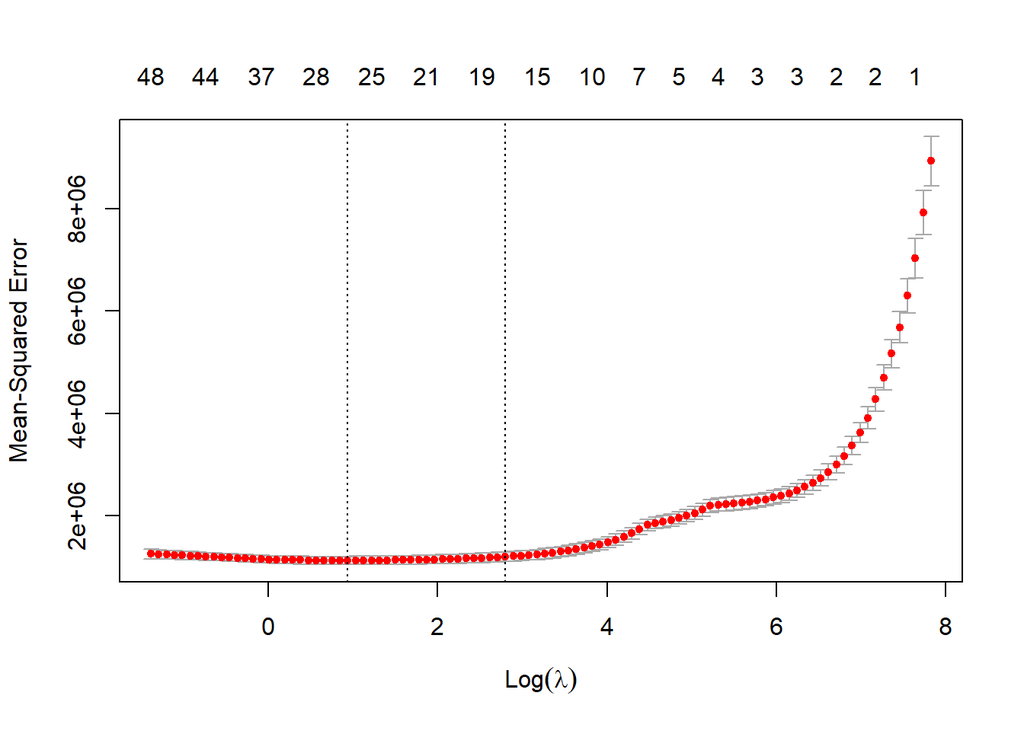

```r
plot(cv_fit22)
```

```r
coef(cv_fit22,s='lambda.1se')
```

```
## 49 x 1 sparse Matrix of class "dgCMatrix"
##                              1
## (Intercept)       4.092444e+03
## lag48_0tüketim    .
## lag48_1tüketim    .
## lag48_2tüketim    .
## lag48_3tüketim   -1.080405e-02
## lag48_4tüketim   -1.931612e-02
## lag48_5tüketim    .
## lag48_6tüketim    .
## lag48_7tüketim    .
## lag48_8tüketim    .
## lag48_9tüketim    .
## lag48_10tüketim  -3.164412e-02
## lag48_11tüketim  -4.567485e-01
## lag48_12tüketim   .
## lag48_13tüketim   .
## lag48_14tüketim   .
## lag48_15tüketim   1.262237e-01
## lag48_16tüketim   .
## lag48_17tüketim   .
## lag48_18tüketim   .
## lag48_19tüketim   8.743678e-02
## lag48_20tüketim   .
## lag48_21tüketim   .
## lag48_22tüketim   5.805269e-05
## lag48_23tüketim   1.142731e+00
## lag168_0tüketim   1.437590e-01
## lag168_1tüketim   4.805712e-03
## lag168_2tüketim   .
## lag168_3tüketim   .
## lag168_4tüketim  -7.439411e-03
## lag168_5tüketim   .
## lag168_6tüketim   .
## lag168_7tüketim   .
## lag168_8tüketim   1.406700e-01
## lag168_9tüketim   2.734439e-01
## lag168_10tüketim  .
## lag168_11tüketim  .
## lag168_12tüketim  .
## lag168_13tüketim  5.774025e-02
## lag168_14tüketim  3.840623e-02
## lag168_15tüketim  2.290239e-02
## lag168_16tüketim  3.213720e-03
## lag168_17tüketim  .
## lag168_18tüketim  .
## lag168_19tüketim  .
## lag168_20tüketim  .
## lag168_21tüketim -1.973557e-01
## lag168_22tüketim -2.551404e-01
## lag168_23tüketim -1.229158e-01
```

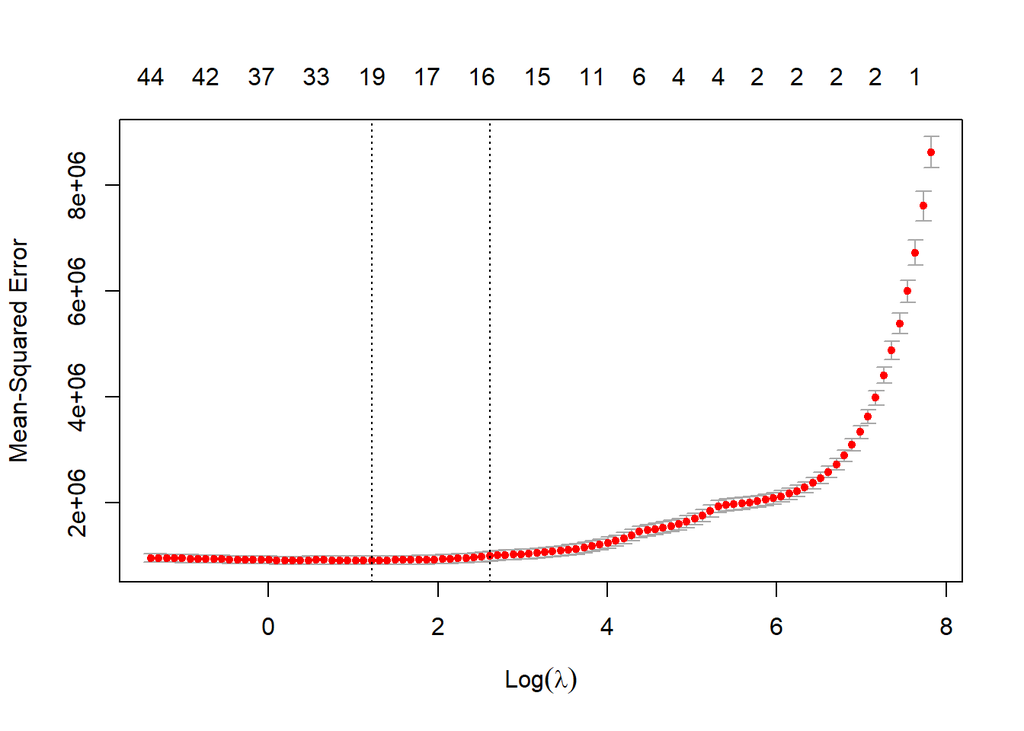

```r
plot(cv_fit23)
```

```r
coef(cv_fit23,s='lambda.1se')
```

```
## 49 x 1 sparse Matrix of class "dgCMatrix"
##                             1
## (Intercept)      572.62982768
## lag48_0tüketim     .
## lag48_1tüketim     .
## lag48_2tüketim    -0.07631295
## lag48_3tüketim     .
## lag48_4tüketim    -0.05157019
## lag48_5tüketim     .
## lag48_6tüketim     .
## lag48_7tüketim     .
## lag48_8tüketim     0.06466580
## lag48_9tüketim     .
## lag48_10tüketim   -0.51262781
## lag48_11tüketim    .
## lag48_12tüketim    .
## lag48_13tüketim    .
## lag48_14tüketim    0.09899075
## lag48_15tüketim    .
## lag48_16tüketim    .
## lag48_17tüketim    .
## lag48_18tüketim    0.05235017
## lag48_19tüketim    .
## lag48_20tüketim    .
## lag48_21tüketim    .
## lag48_22tüketim    .
## lag48_23tüketim    1.30865402
## lag168_0tüketim    0.13380384
## lag168_1tüketim    .
## lag168_2tüketim    .
## lag168_3tüketim   -0.01430550
## lag168_4tüketim    .
## lag168_5tüketim    .
## lag168_6tüketim    .
## lag168_7tüketim    0.09182299
## lag168_8tüketim    0.29130991
## lag168_9tüketim    .
## lag168_10tüketim   .
## lag168_11tüketim   .
## lag168_12tüketim   .
## lag168_13tüketim   0.04429476
## lag168_14tüketim   .
## lag168_15tüketim   .
## lag168_16tüketim   .
## lag168_17tüketim   .
## lag168_18tüketim   .
## lag168_19tüketim   .
## lag168_20tüketim  -0.08449574
## lag168_21tüketim  -0.17354897
## lag168_22tüketim  -0.05399196
## lag168_23tüketim  -0.10818001
```

Prediction for each hour.

```r
predicted_model0=predict(cv_fit0,data.matrix(testdata0[,-c(1,2,3,4,5,54)]),s='lambda.min')
predicted_model1=predict(cv_fit1,data.matrix(testdata1[,-c(1,2,3,4,5,54)]),s='lambda.min')
predicted_model2=predict(cv_fit2,data.matrix(testdata2[,-c(1,2,3,4,5,54)]),s='lambda.min')
predicted_model3=predict(cv_fit3,data.matrix(testdata3[,-c(1,2,3,4,5,54)]),s='lambda.min')
predicted_model4=predict(cv_fit4,data.matrix(testdata4[,-c(1,2,3,4,5,54)]),s='lambda.min')
predicted_model5=predict(cv_fit5,data.matrix(testdata5[,-c(1,2,3,4,5,54)]),s='lambda.min')
predicted_model6=predict(cv_fit6,data.matrix(testdata6[,-c(1,2,3,4,5,54)]),s='lambda.min')
predicted_model7=predict(cv_fit7,data.matrix(testdata7[,-c(1,2,3,4,5,54)]),s='lambda.min')
predicted_model8=predict(cv_fit8,data.matrix(testdata8[,-c(1,2,3,4,5,54)]),s='lambda.min')
predicted_model9=predict(cv_fit9,data.matrix(testdata9[,-c(1,2,3,4,5,54)]),s='lambda.min')
predicted_model10=predict(cv_fit10,data.matrix(testdata10[,-c(1,2,3,4,5,54)]),s='lambda.min')
predicted_model11=predict(cv_fit11,data.matrix(testdata11[,-c(1,2,3,4,5,54)]),s='lambda.min')
predicted_model12=predict(cv_fit12,data.matrix(testdata12[,-c(1,2,3,4,5,54)]),s='lambda.min')
predicted_model13=predict(cv_fit13,data.matrix(testdata13[,-c(1,2,3,4,5,54)]),s='lambda.min')
predicted_model14=predict(cv_fit14,data.matrix(testdata14[,-c(1,2,3,4,5,54)]),s='lambda.min')
predicted_model15=predict(cv_fit15,data.matrix(testdata15[,-c(1,2,3,4,5,54)]),s='lambda.min')
predicted_model16=predict(cv_fit16,data.matrix(testdata16[,-c(1,2,3,4,5,54)]),s='lambda.min')
predicted_model17=predict(cv_fit17,data.matrix(testdata17[,-c(1,2,3,4,5,54)]),s='lambda.min')
predicted_model18=predict(cv_fit18,data.matrix(testdata18[,-c(1,2,3,4,5,54)]),s='lambda.min')
predicted_model19=predict(cv_fit19,data.matrix(testdata19[,-c(1,2,3,4,5,54)]),s='lambda.min')
predicted_model20=predict(cv_fit20,data.matrix(testdata20[,-c(1,2,3,4,5,54)]),s='lambda.min')
predicted_model21=predict(cv_fit21,data.matrix(testdata21[,-c(1,2,3,4,5,54)]),s='lambda.min')
predicted_model22=predict(cv_fit22,data.matrix(testdata22[,-c(1,2,3,4,5,54)]),s='lambda.min')
predicted_model23=predict(cv_fit23,data.matrix(testdata23[,-c(1,2,3,4,5,54)]),s='lambda.min')
```

I calculated MAPE and added them to the dataframe.

```r
testdata0<-mutate(testdata0,MAPE=(abs((testdata0$Tüketim.Miktarı..MWh.-predicted_model0)/testdata0$Tüketim.Miktarı..MWh.)*100))
testdata1<-mutate(testdata1,MAPE=(abs((testdata1$Tüketim.Miktarı..MWh.-predicted_model1)/testdata1$Tüketim.Miktarı..MWh.)*100))
testdata2<-mutate(testdata2,MAPE=(abs((testdata2$Tüketim.Miktarı..MWh.-predicted_model2)/testdata2$Tüketim.Miktarı..MWh.)*100))
testdata3<-mutate(testdata3,MAPE=(abs((testdata3$Tüketim.Miktarı..MWh.-predicted_model3)/testdata3$Tüketim.Miktarı..MWh.)*100))
testdata4<-mutate(testdata4,MAPE=(abs((testdata4$Tüketim.Miktarı..MWh.-predicted_model4)/testdata4$Tüketim.Miktarı..MWh.)*100))
testdata5<-mutate(testdata5,MAPE=(abs((testdata5$Tüketim.Miktarı..MWh.-predicted_model5)/testdata5$Tüketim.Miktarı..MWh.)*100))
testdata6<-mutate(testdata6,MAPE=(abs((testdata6$Tüketim.Miktarı..MWh.-predicted_model6)/testdata6$Tüketim.Miktarı..MWh.)*100))
testdata7<-mutate(testdata7,MAPE=(abs((testdata7$Tüketim.Miktarı..MWh.-predicted_model7)/testdata7$Tüketim.Miktarı..MWh.)*100))
testdata8<-mutate(testdata8,MAPE=(abs((testdata8$Tüketim.Miktarı..MWh.-predicted_model8)/testdata8$Tüketim.Miktarı..MWh.)*100))
testdata9<-mutate(testdata9,MAPE=(abs((testdata9$Tüketim.Miktarı..MWh.-predicted_model9)/testdata9$Tüketim.Miktarı..MWh.)*100))
testdata10<-mutate(testdata10,MAPE=(abs((testdata10$Tüketim.Miktarı..MWh.-predicted_model10)/testdata10$Tüketim.Miktarı..MWh.)*100))
testdata11<-mutate(testdata11,MAPE=(abs((testdata11$Tüketim.Miktarı..MWh.-predicted_model11)/testdata11$Tüketim.Miktarı..MWh.)*100))
testdata12<-mutate(testdata12,MAPE=(abs((testdata12$Tüketim.Miktarı..MWh.-predicted_model12)/testdata12$Tüketim.Miktarı..MWh.)*100))
testdata13<-mutate(testdata13,MAPE=(abs((testdata13$Tüketim.Miktarı..MWh.-predicted_model13)/testdata13$Tüketim.Miktarı..MWh.)*100))
testdata14<-mutate(testdata14,MAPE=(abs((testdata14$Tüketim.Miktarı..MWh.-predicted_model14)/testdata14$Tüketim.Miktarı..MWh.)*100))
testdata15<-mutate(testdata15,MAPE=(abs((testdata15$Tüketim.Miktarı..MWh.-predicted_model15)/testdata15$Tüketim.Miktarı..MWh.)*100))
testdata16<-mutate(testdata16,MAPE=(abs((testdata16$Tüketim.Miktarı..MWh.-predicted_model16)/testdata16$Tüketim.Miktarı..MWh.)*100))
testdata17<-mutate(testdata17,MAPE=(abs((testdata17$Tüketim.Miktarı..MWh.-predicted_model17)/testdata17$Tüketim.Miktarı..MWh.)*100))
testdata18<-mutate(testdata18,MAPE=(abs((testdata18$Tüketim.Miktarı..MWh.-predicted_model18)/testdata18$Tüketim.Miktarı..MWh.)*100))
testdata19<-mutate(testdata19,MAPE=(abs((testdata19$Tüketim.Miktarı..MWh.-predicted_model19)/testdata19$Tüketim.Miktarı..MWh.)*100))
testdata20<-mutate(testdata20,MAPE=(abs((testdata20$Tüketim.Miktarı..MWh.-predicted_model20)/testdata20$Tüketim.Miktarı..MWh.)*100))
testdata21<-mutate(testdata21,MAPE=(abs((testdata21$Tüketim.Miktarı..MWh.-predicted_model21)/testdata21$Tüketim.Miktarı..MWh.)*100))
testdata22<-mutate(testdata22,MAPE=(abs((testdata22$Tüketim.Miktarı..MWh.-predicted_model22)/testdata22$Tüketim.Miktarı..MWh.)*100))
testdata23<-mutate(testdata23,MAPE=(abs((testdata23$Tüketim.Miktarı..MWh.-predicted_model23)/testdata23$Tüketim.Miktarı..MWh.)*100))
```

Summary of MAPE values.

```r
summary(testdata0$MAPE)
```

```
##        1
##  Min.   : 0.00847
##  1st Qu.: 0.82937
##  Median : 1.90940
##  Mean   : 2.41073
##  3rd Qu.: 3.18635
##  Max.   :18.74973
```

```r
summary(testdata1$MAPE)
```

```
##        1
##  Min.   : 0.003509
##  1st Qu.: 0.856315
##  Median : 1.891588
##  Mean   : 2.476845
##  3rd Qu.: 3.238606
##  Max.   :20.822983
```

```r
summary(testdata2$MAPE)
```

```
##        1
##  Min.   : 0.01158
##  1st Qu.: 0.88350
##  Median : 1.81198
##  Mean   : 2.35195
##  3rd Qu.: 3.05137
##  Max.   :22.55331
```

```r
summary(testdata3$MAPE)
```

```
##        1
##  Min.   : 0.008993
##  1st Qu.: 0.838909
##  Median : 2.041200
##  Mean   : 2.634386
##  3rd Qu.: 3.414160
##  Max.   :26.244107
```

```r
summary(testdata4$MAPE)
```

```
##        1
##  Min.   : 0.001478
##  1st Qu.: 0.671697
##  Median : 1.607561
##  Mean   : 2.196341
##  3rd Qu.: 2.798000
##  Max.   :28.064601
```

```r
summary(testdata5$MAPE)
```

```
##        1
##  Min.   : 0.007776
##  1st Qu.: 0.699323
##  Median : 1.589064
##  Mean   : 2.480312
##  3rd Qu.: 2.998085
##  Max.   :24.153329
```

```r
summary(testdata6$MAPE)
```

```
##        1
##  Min.   : 0.003551
##  1st Qu.: 0.751597
##  Median : 1.660294
##  Mean   : 2.608554
##  3rd Qu.: 3.110902
##  Max.   :27.525972
```

```r
summary(testdata7$MAPE)
```

```
##        1
##  Min.   : 0.01243
##  1st Qu.: 0.92878
##  Median : 2.13637
##  Mean   : 3.32483
##  3rd Qu.: 3.95852
##  Max.   :33.80531
```

```r
summary(testdata8$MAPE)
```

```
##        1
##  Min.   : 0.00497
##  1st Qu.: 1.38260
##  Median : 2.98363
##  Mean   : 5.06561
##  3rd Qu.: 5.90564
##  Max.   :50.66795
```

```r
summary(testdata9$MAPE)
```

```
##        1
##  Min.   : 0.00613
##  1st Qu.: 1.62414
##  Median : 3.66559
##  Mean   : 6.07846
##  3rd Qu.: 7.23969
##  Max.   :56.51524
```

```r
summary(testdata10$MAPE)
```

```
##        1
##  Min.   : 0.04371
##  1st Qu.: 1.77427
##  Median : 3.67158
##  Mean   : 6.01019
##  3rd Qu.: 7.27596
##  Max.   :57.93902
```

```r
summary(testdata11$MAPE)
```

```
##        1
##  Min.   : 0.01809
##  1st Qu.: 1.73041
##  Median : 3.92221
##  Mean   : 5.66143
##  3rd Qu.: 6.82571
##  Max.   :55.14950
```

```r
summary(testdata12$MAPE)
```

```
##        1
##  Min.   : 0.00393
##  1st Qu.: 1.91341
##  Median : 4.03909
##  Mean   : 5.54981
##  3rd Qu.: 7.15167
##  Max.   :49.76422
```

```r
summary(testdata13$MAPE)
```

```
##        1
##  Min.   : 0.01112
##  1st Qu.: 1.76492
##  Median : 3.96353
##  Mean   : 5.70022
##  3rd Qu.: 7.47692
##  Max.   :48.19113
```

```r
summary(testdata14$MAPE)
```

```
##        1
##  Min.   : 0.01159
##  1st Qu.: 1.89427
##  Median : 4.06458
##  Mean   : 5.81735
##  3rd Qu.: 7.63990
##  Max.   :46.38612
```

```r
summary(testdata15$MAPE)
```

```
##        1
##  Min.   : 0.02029
##  1st Qu.: 1.81387
##  Median : 3.87145
##  Mean   : 5.59577
##  3rd Qu.: 7.43690
##  Max.   :40.76969
```

```r
summary(testdata16$MAPE)
```

```
##        1
##  Min.   : 0.06348
##  1st Qu.: 1.68786
##  Median : 3.71854
##  Mean   : 5.25092
##  3rd Qu.: 7.19109
##  Max.   :36.90949
```

```r
summary(testdata17$MAPE)
```

```
##        1
##  Min.   : 0.01819
##  1st Qu.: 1.65458
##  Median : 3.48709
##  Mean   : 4.67362
##  3rd Qu.: 6.10536
##  Max.   :32.89943
```

```r
summary(testdata18$MAPE)
```

```
##        1
##  Min.   : 0.00496
##  1st Qu.: 1.38019
##  Median : 2.74742
##  Mean   : 3.90982
##  3rd Qu.: 5.20881
##  Max.   :36.35052
```

```r
summary(testdata19$MAPE)
```

```
##        1
##  Min.   : 0.02738
##  1st Qu.: 1.25071
##  Median : 2.48481
##  Mean   : 3.35684
##  3rd Qu.: 4.56294
##  Max.   :29.89570
```

```r
summary(testdata20$MAPE)
```

```
##        1
##  Min.   : 0.00537
##  1st Qu.: 0.95801
##  Median : 2.03359
##  Mean   : 2.77603
##  3rd Qu.: 3.62409
##  Max.   :23.82822
```

```r
summary(testdata21$MAPE)
```

```
##        1
##  Min.   : 0.004169
##  1st Qu.: 1.205022
##  Median : 2.505210
##  Mean   : 3.098680
##  3rd Qu.: 4.376319
##  Max.   :23.576565
```

```r
summary(testdata22$MAPE)
```

```
##        1
##  Min.   : 0.02553
##  1st Qu.: 0.96263
##  Median : 2.00159
##  Mean   : 2.73869
##  3rd Qu.: 3.74560
##  Max.   :20.05587
```

```r
summary(testdata23$MAPE)
```

```
##        1
##  Min.   : 0.004857
##  1st Qu.: 0.869583
##  Median : 1.995399
##  Mean   : 2.530814
##  3rd Qu.: 3.479534
##  Max.   :17.140947
```